# Unsupervised Learning : Discovering Latent Dimensions using Exploratory Factor Analysis with Extraction and Rotation Method Combinations

```r
##################################
# Conducting exploratory factor analysis
# using Principal Axes extraction
# and Varimax rotation
# with 5 factors
##################################
(FA_PA_V_5F <- fa(DPA.Descriptors.Numeric,
              nfactors = 5,
              fm="pa",
              rotate = "varimax",
              residuals=TRUE,
              SMC=TRUE,
              n.obs=nrow(DPA.Descriptors.Numeric)))
```

```
## Factor Analysis using method =  pa
## Call: fa(r = DPA.Descriptors.Numeric, nfactors = 5, n.obs = nrow(DPA.Descriptors.Numeric),
##     rotate = "varimax", residuals = TRUE, SMC = TRUE, fm = "pa")
## Standardized loadings (pattern matrix) based upon correlation matrix
##       PA5  PA4   PA2  PA3  PA1   h2    u2 com
## ACAD 0.82 0.21  0.21 0.14 0.14 0.79 0.208 1.4
## APPR 0.27 0.66  0.32 0.18 0.05 0.64 0.355 2.0
## COMM 0.14 0.25  0.83 0.21 0.19 0.86 0.143 1.5
## CFIT 0.29 0.21  0.38 0.20 0.74 0.86 0.144 2.2
## EXPR 0.70 0.17 -0.06 0.33 0.19 0.67 0.331 1.8
## JFIT 0.37 0.24  0.23 0.21 0.80 0.93 0.065 2.0
## LETT 0.17 0.07  0.18 0.89 0.21 0.89 0.105 1.3
## LIKE 0.16 0.72  0.25 0.19 0.24 0.69 0.306 1.8
## ORGN 0.09 0.32  0.83 0.08 0.26 0.89 0.115 1.6
## POTL 0.78 0.28  0.18 0.13 0.36 0.87 0.132 1.9
## RESM 0.28 0.31  0.13 0.82 0.10 0.87 0.127 1.6
## SCON 0.22 0.86  0.16 0.09 0.17 0.85 0.153 1.3
##
##                        PA5  PA4  PA2  PA3  PA1
## SS loadings           2.26 2.21 1.90 1.82 1.63
## Proportion Var        0.19 0.18 0.16 0.15 0.14
## Cumulative Var        0.19 0.37 0.53 0.68 0.82
## Proportion Explained  0.23 0.23 0.19 0.19 0.17
## Cumulative Proportion 0.23 0.46 0.65 0.83 1.00
##
## Mean item complexity =  1.7
## Test of the hypothesis that 5 factors are sufficient.
##
## The degrees of freedom for the null model are  66  and the objective function was  10.7 with Chi Square of  472.51
## The degrees of freedom for the model are 16  and the objective function was  0.47
##
## The root mean square of the residuals (RMSR) is  0.01
## The df corrected root mean square of the residuals is  0.03
##
## The harmonic number of observations is  50 with the empirical chi square  1.45  with prob <  1
## The total number of observations was  50  with Likelihood Chi Square =  19.16  with prob <  0.26
##
## Tucker Lewis Index of factoring reliability =  0.965
## RMSEA index =  0.06  and the 90 % confidence intervals are  0 0.153
## BIC =  -43.43
## Fit based upon off diagonal values = 1
## Measures of factor score adequacy
##                                                    PA5  PA4  PA2  PA3  PA1
## Correlation of (regression) scores with factors   0.92 0.92 0.94 0.95 0.94
## Multiple R square of scores with factors          0.85 0.85 0.88 0.91 0.88
## Minimum correlation of possible factor scores     0.71 0.70 0.77 0.82 0.76
```

```r
(FA_PA_V_5F_Summary <- FA_PA_V_5F %>%
  model_parameters(sort = TRUE, threshold = "max"))
```

```
## # Rotated loadings from Factor Analysis (varimax-rotation)
##
## Variable | PA5  | PA4  | PA2  | PA3  | PA1  | Complexity | Uniqueness
## ---------------------------------------------------------------------
## ACAD     | 0.82 |      |      |      |      |    1.41    |    0.21
## POTL     | 0.78 |      |      |      |      |    1.92    |    0.13
## EXPR     | 0.70 |      |      |      |      |    1.77    |    0.33
## SCON     |      | 0.86 |      |      |      |    1.32    |    0.15
## LIKE     |      | 0.72 |      |      |      |    1.75    |    0.31
## APPR     |      | 0.66 |      |      |      |    1.99    |    0.36
## COMM     |      |      | 0.83 |      |      |    1.49    |    0.14
## ORGN     |      |      | 0.83 |      |      |    1.57    |    0.11
## LETT     |      |      |      | 0.89 |      |    1.29    |    0.11
## RESM     |      |      |      | 0.82 |      |    1.63    |    0.13
## JFIT     |      |      |      |      | 0.80 |    1.97    |    0.07
## CFIT     |      |      |      |      | 0.74 |    2.24    |    0.14
##
## The 5 latent factors (varimax rotation) accounted for 81.80% of the total variance of the original data (PA5 = 18.81%, PA4 = 18.44%, PA2 = 15.86%, PA3 = 15.15%, PA1 = 13.55%).
```

```r
summary(FA_PA_V_5F_Summary)
```

```
## # (Explained) Variance of Components
##
## Parameter                       |   PA5 |   PA4 |   PA2 |   PA3 |   PA1
## -----------------------------------------------------------------------
## Eigenvalues                     | 6.211 | 1.294 | 0.967 | 0.867 | 0.477
## Variance Explained              | 0.188 | 0.184 | 0.159 | 0.152 | 0.135
## Variance Explained (Cumulative) | 0.188 | 0.372 | 0.531 | 0.683 | 0.818
## Variance Explained (Proportion) | 0.230 | 0.225 | 0.194 | 0.185 | 0.166
```

```r
##################################
# Extracting the residuals
# from the Exploratory Factor Analysis
##################################
(FA_PA_V_5F_Residual <- residuals(FA_PA_V_5F,
                              diag=FALSE,
                              na.rm=TRUE))
```

```
##      ACAD  APPR  COMM  CFIT  EXPR  JFIT  LETT  LIKE  ORGN  POTL  RESM
## ACAD    NA
## APPR  0.01    NA
## COMM  0.01 -0.02    NA
## CFIT  0.01  0.00  0.00    NA
## EXPR  0.00 -0.04  0.00 -0.03    NA
## JFIT  0.00  0.00  0.00  0.00  0.01    NA
## LETT -0.02 -0.01 -0.01  0.00  0.02 -0.01    NA
## LIKE  0.01  0.00  0.00 -0.02 -0.02  0.02  0.02    NA
## ORGN -0.01  0.01  0.00  0.00  0.02  0.00  0.02  0.00    NA
## POTL -0.01  0.02 -0.01  0.01  0.01 -0.01  0.01  0.01  0.00    NA
## RESM  0.01  0.03  0.01  0.02 -0.02  0.00  0.00 -0.01 -0.03 -0.01    NA
## SCON -0.02 -0.01  0.01  0.01  0.05 -0.01 -0.01  0.01  0.01 -0.02 -0.01
## [1]    NA
```

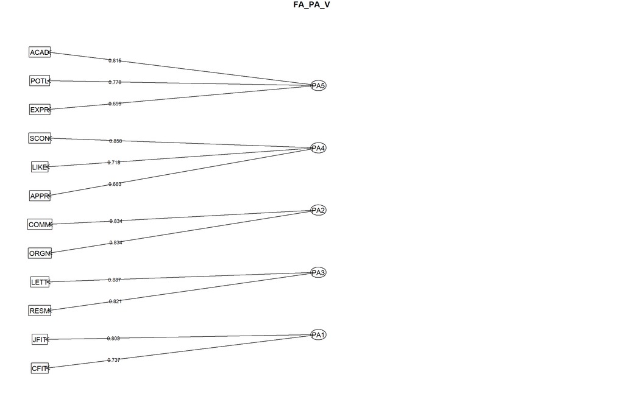

```r
##################################
# Graph the factor loading matrices
##################################
fa.diagram(FA_PA_V_5F,
           sort=TRUE,
           cut=0,
           digits=3,
           main="FA_PA_V",
           cex=0.75)
```

```r
##################################
# computing the internal consistency
# measure of reliability using the
# Cronbach's alpha coefficient
# for each factor
##################################
alpha(DPA.Descriptors.Numeric[,c("ACAD","POTL","EXPR")])
```

```
##
## Reliability analysis
## Call: alpha(x = DPA.Descriptors.Numeric[, c("ACAD", "POTL", "EXPR")])
##
##   raw_alpha std.alpha G6(smc) average_r S/N   ase mean  sd median_r
##       0.89      0.89    0.85      0.72 7.8 0.028  7.3 1.2      0.7
##
##     95% confidence boundaries
##          lower alpha upper
## Feldt     0.82  0.89  0.93
## Duhachek  0.83  0.89  0.94
##
##  Reliability if an item is dropped:
##      raw_alpha std.alpha G6(smc) average_r S/N alpha se var.r med.r
## ACAD      0.83      0.83    0.70      0.70 4.7    0.049    NA  0.70
## POTL      0.80      0.80    0.67      0.67 4.0    0.056    NA  0.67
## EXPR      0.88      0.89    0.80      0.80 7.8    0.032    NA  0.80
##
##  Item statistics
##       n raw.r std.r r.cor r.drop mean  sd
## ACAD 50  0.91  0.91  0.85   0.79  7.4 1.3
## POTL 50  0.92  0.92  0.88   0.82  7.3 1.4
## EXPR 50  0.88  0.88  0.76   0.72  7.3 1.4
##
## Non missing response frequency for each item
##         4    5    6    7    8    9   10 miss
## ACAD 0.02 0.02 0.22 0.28 0.24 0.18 0.04    0
## POTL 0.04 0.06 0.18 0.22 0.30 0.18 0.02    0
## EXPR 0.00 0.10 0.20 0.24 0.24 0.18 0.04    0
```

```r
alpha(DPA.Descriptors.Numeric[,c("SCON","LIKE","APPR")])
```

```
##
## Reliability analysis
## Call: alpha(x = DPA.Descriptors.Numeric[, c("SCON", "LIKE", "APPR")])
##
##   raw_alpha std.alpha G6(smc) average_r S/N   ase mean   sd median_r
##       0.87      0.87    0.83       0.7 6.9 0.031  7.4 0.99      0.7
##
##     95% confidence boundaries
##          lower alpha upper
## Feldt     0.80  0.87  0.92
## Duhachek  0.81  0.87  0.93
##
##  Reliability if an item is dropped:
##      raw_alpha std.alpha G6(smc) average_r S/N alpha se var.r med.r
## SCON      0.78      0.78    0.64      0.64 3.5    0.062    NA  0.64
## LIKE      0.82      0.82    0.70      0.70 4.6    0.051    NA  0.70
## APPR      0.86      0.86    0.75      0.75 6.1    0.040    NA  0.75
##
##  Item statistics
##       n raw.r std.r r.cor r.drop mean  sd
## SCON 50  0.92  0.91  0.86   0.80  7.3 1.2
## LIKE 50  0.90  0.89  0.82   0.76  7.4 1.1
## APPR 50  0.86  0.87  0.76   0.71  7.4 1.0
##
## Non missing response frequency for each item
##         4    5    6    7    8    9   10 miss
## SCON 0.00 0.08 0.14 0.32 0.28 0.18 0.00    0
## LIKE 0.02 0.04 0.12 0.32 0.36 0.14 0.00    0
## APPR 0.00 0.02 0.16 0.32 0.38 0.10 0.02    0
```

```r
alpha(DPA.Descriptors.Numeric[,c("COMM","ORGN")])
```

```
##
## Reliability analysis
## Call: alpha(x = DPA.Descriptors.Numeric[, c("COMM", "ORGN")])
##
##   raw_alpha std.alpha G6(smc) average_r S/N   ase mean  sd median_r
##       0.92      0.93    0.86      0.86  12 0.021  6.9 1.5     0.86
##
##     95% confidence boundaries
##          lower alpha upper
## Feldt     0.87  0.92  0.96
## Duhachek  0.88  0.92  0.97
##
##  Reliability if an item is dropped:
##      raw_alpha std.alpha G6(smc) average_r S/N alpha se var.r med.r
## COMM      0.80      0.86    0.74      0.86 6.2       NA     0  0.86
## ORGN      0.92      0.86    0.74      0.86 6.2       NA     0  0.86
##
##  Item statistics
##       n raw.r std.r r.cor r.drop mean  sd
## COMM 50  0.96  0.96   0.9   0.86  6.9 1.5
## ORGN 50  0.97  0.96   0.9   0.86  6.9 1.6
##
## Non missing response frequency for each item
##         3    4    5   6    7    8    9   10 miss
## COMM 0.04 0.04 0.06 0.2 0.30 0.28 0.06 0.02    0
## ORGN 0.02 0.04 0.20 0.1 0.24 0.24 0.16 0.00    0
```

```r
alpha(DPA.Descriptors.Numeric[,c("LETT","RESM")])
```

```
##
## Reliability analysis
## Call: alpha(x = DPA.Descriptors.Numeric[, c("LETT", "RESM")])
##
##   raw_alpha std.alpha G6(smc) average_r S/N   ase mean  sd median_r
##       0.91      0.91    0.84      0.84  10 0.025  7.2 1.6     0.84
##
##     95% confidence boundaries
##          lower alpha upper
## Feldt     0.84  0.91  0.95
## Duhachek  0.86  0.91  0.96
##
##  Reliability if an item is dropped:
##      raw_alpha std.alpha G6(smc) average_r S/N alpha se var.r med.r
## LETT      0.83      0.84     0.7      0.84 5.1       NA     0  0.84
## RESM      0.84      0.84     0.7      0.84 5.1       NA     0  0.84
##
##  Item statistics
##       n raw.r std.r r.cor r.drop mean  sd
## LETT 50  0.96  0.96  0.88   0.84  7.2 1.7
## RESM 50  0.96  0.96  0.88   0.84  7.2 1.7
##
## Non missing response frequency for each item
##         4    5    6    7    8    9   10 miss
## LETT 0.06 0.12 0.14 0.22 0.24 0.12 0.10    0
## RESM 0.08 0.06 0.22 0.18 0.16 0.24 0.06    0
```

```r
alpha(DPA.Descriptors.Numeric[,c("JFIT","CFIT")])
```

```
##
## Reliability analysis
## Call: alpha(x = DPA.Descriptors.Numeric[, c("JFIT", "CFIT")])
##
##   raw_alpha std.alpha G6(smc) average_r S/N   ase mean  sd median_r
##       0.94      0.94    0.88      0.88  15 0.018    7 1.6     0.88
##
##     95% confidence boundaries
##          lower alpha upper
## Feldt     0.89  0.94  0.96
## Duhachek  0.90  0.94  0.97
##
##  Reliability if an item is dropped:
##      raw_alpha std.alpha G6(smc) average_r S/N alpha se var.r med.r
## JFIT      0.87      0.88    0.78      0.88 7.5       NA     0  0.88
## CFIT      0.90      0.88    0.78      0.88 7.5       NA     0  0.88
##
##  Item statistics
##       n raw.r std.r r.cor r.drop mean  sd
## JFIT 50  0.97  0.97  0.91   0.88  7.0 1.6
## CFIT 50  0.97  0.97  0.91   0.88  6.9 1.6
##
## Non missing response frequency for each item
##         3    4    5    6    7    8    9   10 miss
## JFIT 0.06 0.00 0.06 0.22 0.26 0.24 0.12 0.04    0
## CFIT 0.02 0.06 0.16 0.12 0.22 0.30 0.08 0.04    0
```

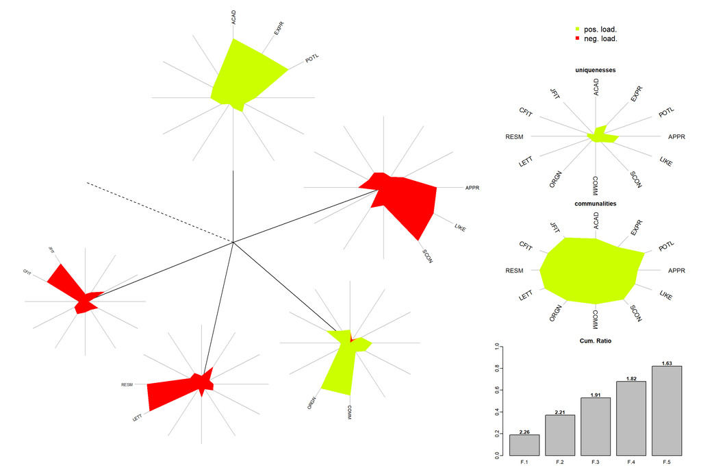

```r
##################################
# Formulating the dandelion plot to
# visualize both factor variances and loadings
# from the factor loading matrices
##################################
FA_PA_V_5F_FactorLoading <- factload(DPA.Descriptors.Numeric,
                                  cormeth = "pearson",
                                  method = "prax",
                                  nfac = 5,
                                  rotation = "varimax")

DandelionPlotPalette <- rev(rainbow(100, start = 0, end = 0.2))

dandelion(FA_PA_V_5F_FactorLoading,
          bound=0,
          mcex=c(1,1.2),
          palet=DandelionPlotPalette)
```

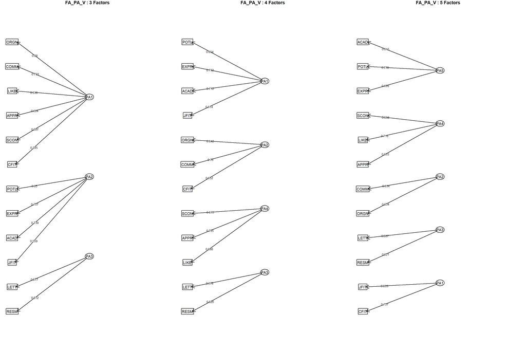

```r
par(mfrow=c(1,3))
fa.diagram(FA_PA_V_3F,
           sort=TRUE,
           cut=0,
           digits=3,
           main="FA_PA_V : 3 Factors",
           cex=0.75)
fa.diagram(FA_PA_V_4F,
           sort=TRUE,
           cut=0,
           digits=3,
           main="FA_PA_V : 4 Factors",
           cex=0.75)
fa.diagram(FA_PA_V_5F,
           sort=TRUE,
           cut=0,
           digits=3,
           main="FA_PA_V : 5 Factors",
           cex=0.75)
```

### 1.6.2 Principal Axes Factor Extraction and Promax Rotation (FA_PA_P)

**Code Chunk | Output**

```r
##################################
# Conducting exploratory factor analysis
# using Principal Axes extraction
# and Promax rotation
# with 3 factors
##################################
(FA_PA_P_3F <- fa(DPA.Descriptors.Numeric,
              nfactors = 3,
              fm="pa",
              rotate = "promax",
              residuals=TRUE,
              SMC=TRUE,
              n.obs=nrow(DPA.Descriptors.Numeric)))
```

```
## Factor Analysis using method =  pa
## Call: fa(r = DPA.Descriptors.Numeric, nfactors = 3, n.obs = nrow(DPA.Descriptors.Numeric),
##     rotate = "promax", residuals = TRUE, SMC = TRUE, fm = "pa")
## Standardized loadings (pattern matrix) based upon correlation matrix
##        PA1   PA2   PA3   h2   u2 com
## ACAD  0.02  0.82 -0.06 0.65 0.35 1.0
## APPR  0.59  0.15  0.02 0.50 0.50 1.1
## COMM  0.91 -0.23  0.10 0.69 0.31 1.1
## CFIT  0.52  0.32  0.04 0.61 0.39 1.7
## EXPR -0.31  0.88  0.19 0.69 0.31 1.3
## JFIT  0.37  0.48  0.04 0.64 0.36 1.9
## LETT  0.03 -0.05  0.94 0.86 0.14 1.0
## LIKE  0.64  0.12  0.03 0.54 0.46 1.1
## ORGN  1.04 -0.24 -0.05 0.79 0.21 1.1
## POTL  0.08  0.95 -0.13 0.87 0.13 1.1
## RESM  0.07  0.09  0.82 0.83 0.17 1.0
## SCON  0.57  0.24 -0.07 0.51 0.49 1.4
##
##                        PA1  PA2  PA3
## SS loadings           3.56 2.92 1.70
## Proportion Var        0.30 0.24 0.14
## Cumulative Var        0.30 0.54 0.68
## Proportion Explained  0.44 0.36 0.21
## Cumulative Proportion 0.44 0.79 1.00
##
##  With factor correlations of
##      PA1  PA2  PA3
## PA1 1.00 0.64 0.48
## PA2 0.64 1.00 0.55
## PA3 0.48 0.55 1.00
##
## Mean item complexity =  1.2
## Test of the hypothesis that 3 factors are sufficient.
##
## The degrees of freedom for the null model are  66  and the objective function was  10.7 with Chi Square of  472.51
## The degrees of freedom for the model are 33  and the objective function was  2.52
##
## The root mean square of the residuals (RMSR) is  0.07
## The df corrected root mean square of the residuals is  0.1
##
## The harmonic number of observations is  50 with the empirical chi square  35.54  with prob <  0.35
## The total number of observations was  50  with Likelihood Chi Square =  106.33  with prob <  1.2e-09
##
## Tucker Lewis Index of factoring reliability =  0.619
## RMSEA index =  0.21  and the 90 % confidence intervals are  0.168 0.259
## BIC =  -22.76
## Fit based upon off diagonal values = 0.98
## Measures of factor score adequacy
##                                                    PA1  PA2  PA3
## Correlation of (regression) scores with factors   0.96 0.97 0.96
## Multiple R square of scores with factors          0.93 0.93 0.91
## Minimum correlation of possible factor scores     0.85 0.86 0.83
```

```r
(FA_PA_P_3F_Summary <- FA_PA_P_3F %>%
  model_parameters(sort = TRUE, threshold = "max"))
```

```
## # Rotated loadings from Factor Analysis (promax-rotation)
##
## Variable | PA1  | PA2  | PA3  | Complexity | Uniqueness
## -------------------------------------------------------
## ORGN     | 1.04 |      |      |    1.11    |    0.21
## COMM     | 0.91 |      |      |    1.15    |    0.31
## LIKE     | 0.64 |      |      |    1.07    |    0.46
## APPR     | 0.59 |      |      |    1.13    |    0.50
## SCON     | 0.57 |      |      |    1.37    |    0.49
## CFIT     | 0.52 |      |      |    1.67    |    0.39
## POTL     |      | 0.95 |      |    1.05    |    0.13
## EXPR     |      | 0.88 |      |    1.34    |    0.31
## ACAD     |      | 0.82 |      |    1.01    |    0.35
## JFIT     |      | 0.48 |      |    1.91    |    0.36
## LETT     |      |      | 0.94 |    1.01    |    0.14
## RESM     |      |      | 0.82 |    1.04    |    0.17
##
## The 3 latent factors (promax rotation) accounted for 68.18% of the total variance of the original data (PA1 = 29.69%, PA2 = 24.31%, PA3 = 14.19%).
```

```r
summary(FA_PA_P_3F_Summary)
```

```
## # (Explained) Variance of Components
##
## Parameter                       |   PA1 |   PA2 |   PA3
## -------------------------------------------------------
## Eigenvalues                     | 6.069 | 1.209 | 0.903
## Variance Explained              | 0.297 | 0.243 | 0.142
## Variance Explained (Cumulative) | 0.297 | 0.540 | 0.682
## Variance Explained (Proportion) | 0.435 | 0.357 | 0.208
```

```r
##################################
# Extracting the residuals
# from the Exploratory Factor Analysis
##################################
(FA_PA_P_3F_Residual <- residuals(FA_PA_P_3F,
                              diag=FALSE,
                              na.rm=TRUE))
```

```
##      ACAD  APPR  COMM  CFIT  EXPR  JFIT  LETT  LIKE  ORGN  POTL  RESM
## ACAD    NA
## APPR  0.03    NA
## COMM  0.07 -0.06    NA
## CFIT -0.04 -0.13  0.02    NA
## EXPR  0.04 -0.02  0.00 -0.06    NA
## JFIT -0.06 -0.12 -0.01  0.27 -0.01    NA
## LETT -0.02 -0.05  0.01  0.04  0.02  0.03    NA
## LIKE -0.04  0.12 -0.09 -0.08 -0.03 -0.02 -0.01    NA
## ORGN  0.03 -0.04  0.13  0.04  0.03  0.00  0.03 -0.08    NA
## POTL  0.04  0.00  0.02  0.03 -0.01  0.01  0.01 -0.03  0.01    NA
## RESM  0.02  0.09 -0.01 -0.05 -0.01 -0.05  0.00  0.04 -0.06 -0.02    NA
## SCON -0.06  0.20 -0.10 -0.09  0.05 -0.08 -0.07  0.24 -0.08 -0.05  0.06
## [1]    NA
```

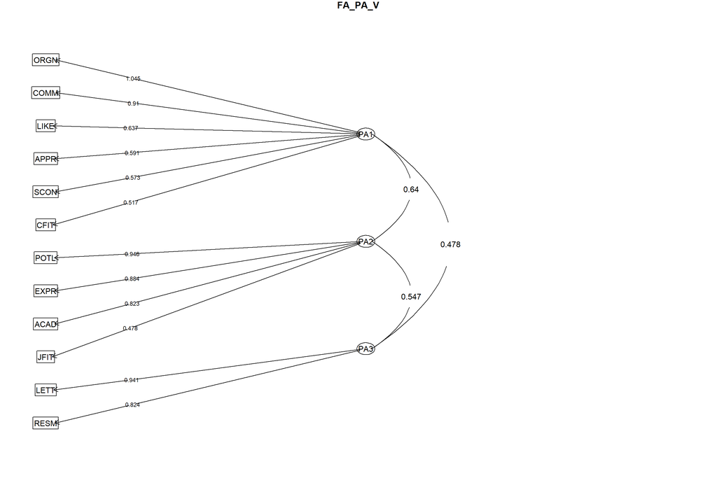

```r
##################################
# Graph the factor loading matrices
##################################
fa.diagram(FA_PA_P_3F,
           sort=TRUE,
           cut=0,
           digits=3,
           main="FA_PA_V",
           cex=0.75)
```

```r
##################################
# computing the internal consistency
# measure of reliability using the
# Cronbach's alpha coefficient
# for each factor
##################################
alpha(DPA.Descriptors.Numeric[,c("ORGN","COMM","LIKE","APPR","SCON","CFIT")])
```

```
##
## Reliability analysis
## Call: alpha(x = DPA.Descriptors.Numeric[, c("ORGN", "COMM", "LIKE",
##     "APPR", "SCON", "CFIT")])
##
##   raw_alpha std.alpha G6(smc) average_r S/N   ase mean  sd median_r
##       0.88      0.89     0.9      0.57 7.8 0.026  7.1 1.1     0.53
##
##     95% confidence boundaries
##          lower alpha upper
## Feldt     0.82  0.88  0.92
## Duhachek  0.83  0.88  0.93
##
##  Reliability if an item is dropped:
##      raw_alpha std.alpha G6(smc) average_r S/N alpha se var.r med.r
## ORGN      0.84      0.86    0.85      0.55 6.0    0.036 0.014  0.49
## COMM      0.85      0.87    0.86      0.56 6.4    0.034 0.012  0.53
## LIKE      0.86      0.86    0.88      0.56 6.4    0.030 0.019  0.52
## APPR      0.86      0.87    0.89      0.57 6.7    0.030 0.019  0.51
## SCON      0.86      0.87    0.87      0.57 6.5    0.029 0.015  0.53
## CFIT      0.87      0.88    0.90      0.59 7.3    0.029 0.020  0.53
##
##  Item statistics
##       n raw.r std.r r.cor r.drop mean  sd
## ORGN 50  0.87  0.84  0.84   0.78  6.9 1.6
## COMM 50  0.84  0.81  0.79   0.74  6.9 1.5
## LIKE 50  0.78  0.81  0.77   0.69  7.4 1.1
## APPR 50  0.75  0.79  0.73   0.67  7.4 1.0
## SCON 50  0.76  0.80  0.76   0.67  7.3 1.2
## CFIT 50  0.78  0.75  0.66   0.64  6.9 1.6
##
## Non missing response frequency for each item
##         3    4    5    6    7    8    9   10 miss
## ORGN 0.02 0.04 0.20 0.10 0.24 0.24 0.16 0.00    0
## COMM 0.04 0.04 0.06 0.20 0.30 0.28 0.06 0.02    0
## LIKE 0.00 0.02 0.04 0.12 0.32 0.36 0.14 0.00    0
## APPR 0.00 0.00 0.02 0.16 0.32 0.38 0.10 0.02    0
## SCON 0.00 0.00 0.08 0.14 0.32 0.28 0.18 0.00    0
## CFIT 0.02 0.06 0.16 0.12 0.22 0.30 0.08 0.04    0
```

```r
alpha(DPA.Descriptors.Numeric[,c("POTL","EXPR","ACAD","JFIT")])
```

```
##
## Reliability analysis
## Call: alpha(x = DPA.Descriptors.Numeric[, c("POTL", "EXPR", "ACAD",
##     "JFIT")])
##
##   raw_alpha std.alpha G6(smc) average_r S/N   ase mean  sd median_r
##       0.88      0.88    0.87      0.66 7.6 0.028  7.3 1.2     0.69
##
##     95% confidence boundaries
##          lower alpha upper
## Feldt     0.81  0.88  0.93
## Duhachek  0.82  0.88  0.93
##
##  Reliability if an item is dropped:
##      raw_alpha std.alpha G6(smc) average_r S/N alpha se  var.r med.r
## POTL      0.79      0.80    0.74      0.58 4.1    0.051 0.0063  0.54
## EXPR      0.86      0.86    0.84      0.68 6.4    0.036 0.0169  0.71
## ACAD      0.84      0.84    0.80      0.64 5.4    0.040 0.0111  0.70
## JFIT      0.89      0.89    0.85      0.72 7.8    0.028 0.0043  0.70
##
##  Item statistics
##       n raw.r std.r r.cor r.drop mean  sd
## POTL 50  0.93  0.93  0.92   0.87  7.3 1.4
## EXPR 50  0.83  0.84  0.75   0.71  7.3 1.4
## ACAD 50  0.86  0.87  0.83   0.76  7.4 1.3
## JFIT 50  0.82  0.80  0.71   0.65  7.0 1.6
##
## Non missing response frequency for each item
##         3    4    5    6    7    8    9   10 miss
## POTL 0.00 0.04 0.06 0.18 0.22 0.30 0.18 0.02    0
## EXPR 0.00 0.00 0.10 0.20 0.24 0.24 0.18 0.04    0
## ACAD 0.00 0.02 0.02 0.22 0.28 0.24 0.18 0.04    0
## JFIT 0.06 0.00 0.06 0.22 0.26 0.24 0.12 0.04    0
```

```r
alpha(DPA.Descriptors.Numeric[,c("LETT","RESM")])
```

```
##
## Reliability analysis
## Call: alpha(x = DPA.Descriptors.Numeric[, c("LETT", "RESM")])
##
##   raw_alpha std.alpha G6(smc) average_r S/N   ase mean  sd median_r
##       0.91      0.91    0.84      0.84  10 0.025  7.2 1.6     0.84
##
##     95% confidence boundaries
##          lower alpha upper
## Feldt     0.84  0.91  0.95
## Duhachek  0.86  0.91  0.96
##
##  Reliability if an item is dropped:
##      raw_alpha std.alpha G6(smc) average_r S/N alpha se var.r med.r
## LETT      0.83      0.84     0.7      0.84 5.1       NA     0  0.84
## RESM      0.84      0.84     0.7      0.84 5.1       NA     0  0.84
##
##  Item statistics
##       n raw.r std.r r.cor r.drop mean  sd
## LETT 50  0.96  0.96  0.88   0.84  7.2 1.7
## RESM 50  0.96  0.96  0.88   0.84  7.2 1.7
##
## Non missing response frequency for each item
##         4    5    6    7    8    9   10 miss
## LETT 0.06 0.12 0.14 0.22 0.24 0.12 0.10    0
## RESM 0.08 0.06 0.22 0.18 0.16 0.24 0.06    0
```

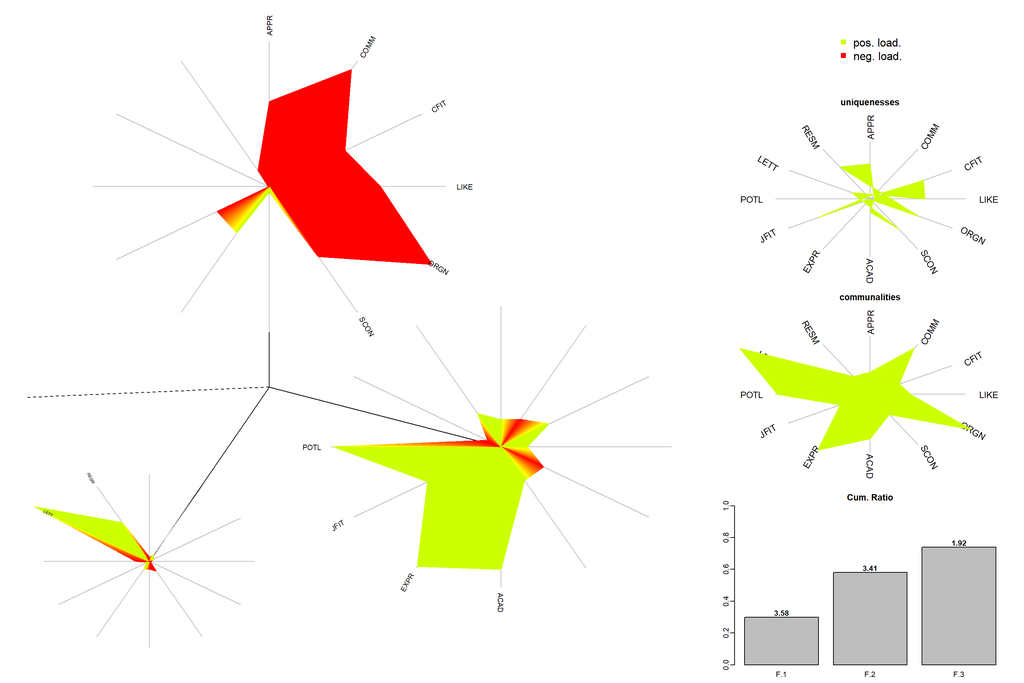

```r
##################################
# Formulating the dandelion plot to
# visualize both factor variances and loadings
# from the factor loading matrices
##################################
FA_PA_P_3F_FactorLoading <- factload(DPA.Descriptors.Numeric,
                                  cormeth = "pearson",
                                  method = "prax",
                                  nfac = 3,
                                  rotation = "promax")

DandelionPlotPalette <- rev(rainbow(100, start = 0, end = 0.2))

dandelion(FA_PA_P_3F_FactorLoading,
          bound=0,
          mcex=c(1,1.2),
          palet=DandelionPlotPalette)
```

```r
##################################
# Conducting exploratory factor analysis
# using Principal Axes extraction
# and Promax rotation
# with 4 factors
##################################
(FA_PA_P_4F <- fa(DPA.Descriptors.Numeric,
              nfactors = 4,
              fm="pa",
              rotate = "promax",
              residuals=TRUE,
              SMC=TRUE,
              n.obs=nrow(DPA.Descriptors.Numeric)))
```

```
## Factor Analysis using method =  pa
## Call: fa(r = DPA.Descriptors.Numeric, nfactors = 4, n.obs = nrow(DPA.Descriptors.Numeric),
##     rotate = "promax", residuals = TRUE, SMC = TRUE, fm = "pa")
## Standardized loadings (pattern matrix) based upon correlation matrix
##        PA1   PA2   PA4   PA3   h2   u2 com
## ACAD  0.77 -0.02  0.11 -0.04 0.64 0.36 1.0
## APPR  0.04  0.09  0.72  0.04 0.65 0.35 1.0
## COMM -0.14  0.82  0.11  0.10 0.73 0.27 1.1
## CFIT  0.44  0.64 -0.14  0.01 0.76 0.24 1.9
## EXPR  0.81 -0.28  0.03  0.19 0.68 0.32 1.4
## JFIT  0.57  0.46 -0.10  0.02 0.73 0.27 2.0
## LETT -0.01  0.14 -0.16  0.95 0.89 0.11 1.1
## LIKE  0.02  0.16  0.68  0.05 0.66 0.34 1.1
## ORGN -0.17  0.92  0.17 -0.05 0.86 0.14 1.1
## POTL  0.94  0.04  0.08 -0.13 0.89 0.11 1.1
## RESM  0.04 -0.08  0.20  0.85 0.88 0.12 1.1
## SCON  0.11 -0.01  0.87 -0.09 0.79 0.21 1.1
##
##                        PA1  PA2  PA4  PA3
## SS loadings           2.85 2.47 2.09 1.74
## Proportion Var        0.24 0.21 0.17 0.15
## Cumulative Var        0.24 0.44 0.62 0.76
## Proportion Explained  0.31 0.27 0.23 0.19
## Cumulative Proportion 0.31 0.58 0.81 1.00
##
##  With factor correlations of
##      PA1  PA2  PA4  PA3
## PA1 1.00 0.53 0.52 0.54
## PA2 0.53 1.00 0.56 0.41
## PA4 0.52 0.56 1.00 0.42
## PA3 0.54 0.41 0.42 1.00
##
## Mean item complexity =  1.3
## Test of the hypothesis that 4 factors are sufficient.
##
## The degrees of freedom for the null model are  66  and the objective function was  10.7 with Chi Square of  472.51
## The degrees of freedom for the model are 24  and the objective function was  1.47
##
## The root mean square of the residuals (RMSR) is  0.04
## The df corrected root mean square of the residuals is  0.06
##
## The harmonic number of observations is  50 with the empirical chi square  9.84  with prob <  1
## The total number of observations was  50  with Likelihood Chi Square =  60.87  with prob <  4.8e-05
##
## Tucker Lewis Index of factoring reliability =  0.732
## RMSEA index =  0.174  and the 90 % confidence intervals are  0.122 0.233
## BIC =  -33.02
## Fit based upon off diagonal values = 0.99
## Measures of factor score adequacy
##                                                    PA1  PA2  PA4  PA3
## Correlation of (regression) scores with factors   0.97 0.96 0.95 0.97
## Multiple R square of scores with factors          0.94 0.93 0.89 0.94
## Minimum correlation of possible factor scores     0.88 0.85 0.79 0.88
```

```r
(FA_PA_P_4F_Summary <- FA_PA_P_4F %>%
  model_parameters(sort = TRUE, threshold = "max"))
```

```
## # Rotated loadings from Factor Analysis (promax-rotation)
##
## Variable | PA1  | PA2  | PA4  | PA3  | Complexity | Uniqueness
## --------------------------------------------------------------
## POTL     | 0.94 |      |      |      |    1.06    |    0.11
## EXPR     | 0.81 |      |      |      |    1.36    |    0.32
## ACAD     | 0.77 |      |      |      |    1.05    |    0.36
## JFIT     | 0.57 |      |      |      |    1.99    |    0.27
## ORGN     |      | 0.92 |      |      |    1.14    |    0.14
## COMM     |      | 0.82 |      |      |    1.13    |    0.27
## CFIT     |      | 0.64 |      |      |    1.88    |    0.24
## SCON     |      |      | 0.87 |      |    1.05    |    0.21
## APPR     |      |      | 0.72 |      |    1.04    |    0.35
## LIKE     |      |      | 0.68 |      |    1.12    |    0.34
## LETT     |      |      |      | 0.95 |    1.11    |    0.11
## RESM     |      |      |      | 0.85 |    1.13    |    0.12
##
## The 4 latent factors (promax rotation) accounted for 76.28% of the total variance of the original data (PA1 = 23.74%, PA2 = 20.58%, PA4 = 17.43%, PA3 = 14.53%).
```

```r
summary(FA_PA_P_4F_Summary)
```

```
## # (Explained) Variance of Components
##
## Parameter                       |   PA1 |   PA2 |   PA4 |   PA3
## ---------------------------------------------------------------
## Eigenvalues                     | 6.152 | 1.259 | 0.943 | 0.800
## Variance Explained              | 0.237 | 0.206 | 0.174 | 0.145
## Variance Explained (Cumulative) | 0.237 | 0.443 | 0.618 | 0.763
## Variance Explained (Proportion) | 0.311 | 0.270 | 0.229 | 0.190
```

```r
##################################
# Extracting the residuals
# from the Exploratory Factor Analysis
##################################
(FA_PA_P_4F_Residual <- residuals(FA_PA_P_4F,
                              diag=FALSE,
                              na.rm=TRUE))
```

```
##      ACAD  APPR  COMM  CFIT  EXPR  JFIT  LETT  LIKE  ORGN  POTL  RESM
## ACAD    NA
## APPR  0.04    NA
## COMM  0.07  0.01    NA
## CFIT -0.06 -0.02 -0.05    NA
## EXPR  0.05 -0.03  0.01 -0.05    NA
## JFIT -0.07 -0.03 -0.07  0.15 -0.01    NA
## LETT -0.03 -0.01 -0.01  0.00  0.02  0.00    NA
## LIKE -0.03 -0.02 -0.03  0.02 -0.03  0.07  0.02    NA
## ORGN  0.03  0.02  0.08 -0.05  0.04 -0.06  0.01 -0.03    NA
## POTL  0.05  0.03  0.01 -0.02  0.00 -0.03  0.01 -0.01  0.01    NA
## RESM  0.02  0.03  0.02  0.01 -0.01 -0.01  0.00 -0.01 -0.03 -0.01    NA
## SCON -0.06 -0.01 -0.03  0.04  0.04  0.03 -0.01  0.05 -0.01 -0.03 -0.01
## [1]    NA
```

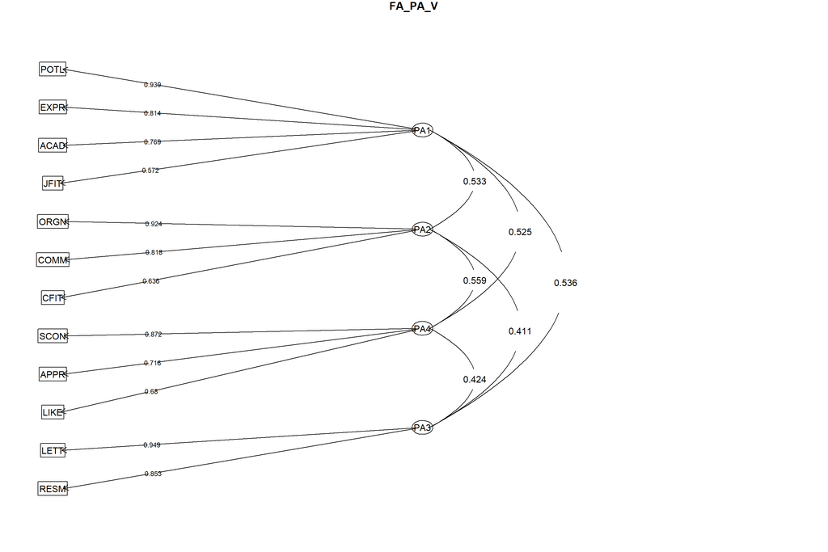

```r
##################################
# Graph the factor loading matrices
##################################
fa.diagram(FA_PA_P_4F,
           sort=TRUE,
           cut=0,
           digits=3,
           main="FA_PA_V",
           cex=0.75)
```

```r
##################################
# computing the internal consistency
# measure of reliability using the
# Cronbach's alpha coefficient
# for each factor
##################################
alpha(DPA.Descriptors.Numeric[,c("POTL","EXPR","ACAD","JFIT")])
```

```
##
## Reliability analysis
## Call: alpha(x = DPA.Descriptors.Numeric[, c("POTL", "EXPR", "ACAD",
##     "JFIT")])
##
##   raw_alpha std.alpha G6(smc) average_r S/N   ase mean  sd median_r
##       0.88      0.88    0.87      0.66 7.6 0.028  7.3 1.2     0.69
##
##     95% confidence boundaries
##          lower alpha upper
## Feldt     0.81  0.88  0.93
## Duhachek  0.82  0.88  0.93
##
##  Reliability if an item is dropped:
##      raw_alpha std.alpha G6(smc) average_r S/N alpha se  var.r med.r
## POTL      0.79      0.80    0.74      0.58 4.1    0.051 0.0063  0.54
## EXPR      0.86      0.86    0.84      0.68 6.4    0.036 0.0169  0.71
## ACAD      0.84      0.84    0.80      0.64 5.4    0.040 0.0111  0.70
## JFIT      0.89      0.89    0.85      0.72 7.8    0.028 0.0043  0.70
##
##  Item statistics
##       n raw.r std.r r.cor r.drop mean  sd
## POTL 50  0.93  0.93  0.92   0.87  7.3 1.4
## EXPR 50  0.83  0.84  0.75   0.71  7.3 1.4
## ACAD 50  0.86  0.87  0.83   0.76  7.4 1.3
## JFIT 50  0.82  0.80  0.71   0.65  7.0 1.6
##
## Non missing response frequency for each item
##         3    4    5    6    7    8    9   10 miss
## POTL 0.00 0.04 0.06 0.18 0.22 0.30 0.18 0.02    0
## EXPR 0.00 0.00 0.10 0.20 0.24 0.24 0.18 0.04    0
## ACAD 0.00 0.02 0.02 0.22 0.28 0.24 0.18 0.04    0
## JFIT 0.06 0.00 0.06 0.22 0.26 0.24 0.12 0.04    0
```

```r
alpha(DPA.Descriptors.Numeric[,c("ORGN","COMM","CFIT")])
```

```
##
## Reliability analysis
## Call: alpha(x = DPA.Descriptors.Numeric[, c("ORGN", "COMM", "CFIT")])
##
##   raw_alpha std.alpha G6(smc) average_r S/N   ase mean  sd median_r
##       0.87      0.87    0.85      0.69 6.7 0.034  6.9 1.4     0.62
##
##     95% confidence boundaries
##          lower alpha upper
## Feldt     0.79  0.87  0.92
## Duhachek  0.80  0.87  0.93
##
##  Reliability if an item is dropped:
##      raw_alpha std.alpha G6(smc) average_r  S/N alpha se var.r med.r
## ORGN      0.74      0.74    0.59      0.59  2.9    0.073    NA  0.59
## COMM      0.77      0.77    0.62      0.62  3.3    0.066    NA  0.62
## CFIT      0.92      0.93    0.86      0.86 12.5    0.021    NA  0.86
##
##  Item statistics
##       n raw.r std.r r.cor r.drop mean  sd
## ORGN 50  0.93  0.93  0.91   0.83  6.9 1.6
## COMM 50  0.91  0.92  0.89   0.80  6.9 1.5
## CFIT 50  0.84  0.83  0.65   0.63  6.9 1.6
##
## Non missing response frequency for each item
##         3    4    5    6    7    8    9   10 miss
## ORGN 0.02 0.04 0.20 0.10 0.24 0.24 0.16 0.00    0
## COMM 0.04 0.04 0.06 0.20 0.30 0.28 0.06 0.02    0
## CFIT 0.02 0.06 0.16 0.12 0.22 0.30 0.08 0.04    0
```

```r
alpha(DPA.Descriptors.Numeric[,c("SCON","APPR","LIKE")])
```

```
##
## Reliability analysis
## Call: alpha(x = DPA.Descriptors.Numeric[, c("SCON", "APPR", "LIKE")])
##
##   raw_alpha std.alpha G6(smc) average_r S/N   ase mean   sd median_r
##       0.87      0.87    0.83       0.7 6.9 0.031  7.4 0.99      0.7
##
##     95% confidence boundaries
##          lower alpha upper
## Feldt     0.80  0.87  0.92
## Duhachek  0.81  0.87  0.93
##
##  Reliability if an item is dropped:
##      raw_alpha std.alpha G6(smc) average_r S/N alpha se var.r med.r
## SCON      0.78      0.78    0.64      0.64 3.5    0.062    NA  0.64
## APPR      0.86      0.86    0.75      0.75 6.1    0.040    NA  0.75
## LIKE      0.82      0.82    0.70      0.70 4.6    0.051    NA  0.70
##
##  Item statistics
##       n raw.r std.r r.cor r.drop mean  sd
## SCON 50  0.92  0.91  0.86   0.80  7.3 1.2
## APPR 50  0.86  0.87  0.76   0.71  7.4 1.0
## LIKE 50  0.90  0.89  0.82   0.76  7.4 1.1
##
## Non missing response frequency for each item
##         4    5    6    7    8    9   10 miss
## SCON 0.00 0.08 0.14 0.32 0.28 0.18 0.00    0
## APPR 0.00 0.02 0.16 0.32 0.38 0.10 0.02    0
## LIKE 0.02 0.04 0.12 0.32 0.36 0.14 0.00    0
```

```r
alpha(DPA.Descriptors.Numeric[,c("LETT","RESM")])
```

```
##
## Reliability analysis
## Call: alpha(x = DPA.Descriptors.Numeric[, c("LETT", "RESM")])
##
##   raw_alpha std.alpha G6(smc) average_r S/N   ase mean  sd median_r
##       0.91      0.91    0.84      0.84  10 0.025  7.2 1.6     0.84
##
##     95% confidence boundaries
##          lower alpha upper
## Feldt     0.84  0.91  0.95
## Duhachek  0.86  0.91  0.96
##
##  Reliability if an item is dropped:
##      raw_alpha std.alpha G6(smc) average_r S/N alpha se var.r med.r
## LETT      0.83      0.84     0.7      0.84 5.1       NA     0  0.84
## RESM      0.84      0.84     0.7      0.84 5.1       NA     0  0.84
##
##  Item statistics
##       n raw.r std.r r.cor r.drop mean  sd
## LETT 50  0.96  0.96  0.88   0.84  7.2 1.7
## RESM 50  0.96  0.96  0.88   0.84  7.2 1.7
##
## Non missing response frequency for each item
##         4    5    6    7    8    9   10 miss
## LETT 0.06 0.12 0.14 0.22 0.24 0.12 0.10    0
## RESM 0.08 0.06 0.22 0.18 0.16 0.24 0.06    0
```

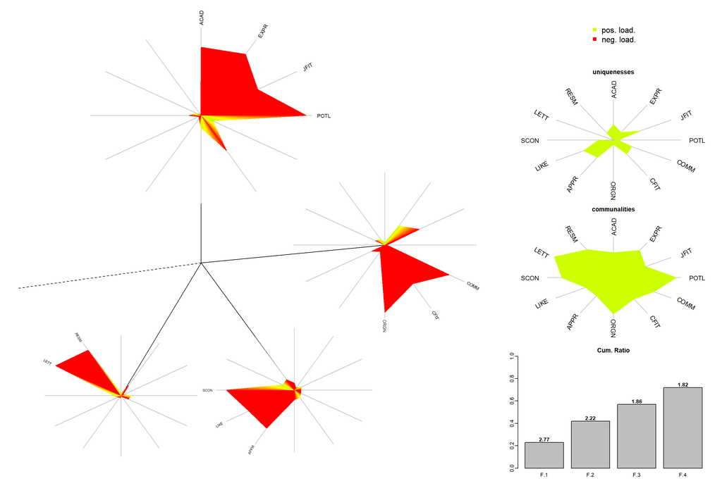

```r
##################################
# Formulating the dandelion plot to
# visualize both factor variances and loadings
# from the factor loading matrices
##################################
FA_PA_P_4F_FactorLoading <- factload(DPA.Descriptors.Numeric,
                                  cormeth = "pearson",
                                  method = "prax",
                                  nfac = 4,
                                  rotation = "promax")

DandelionPlotPalette <- rev(rainbow(100, start = 0, end = 0.2))

dandelion(FA_PA_P_4F_FactorLoading,
          bound=0,
          mcex=c(1,1.2),
          palet=DandelionPlotPalette)
```

```r
##################################
# Conducting exploratory factor analysis
# using Principal Axes extraction
# and Promax rotation
# with 5 factors
##################################
(FA_PA_P_5F <- fa(DPA.Descriptors.Numeric,
              nfactors = 5,
              fm="pa",
              rotate = "promax",
              residuals=TRUE,
              SMC=TRUE,
              n.obs=nrow(DPA.Descriptors.Numeric)))
```

```
## Factor Analysis using method =  pa
## Call: fa(r = DPA.Descriptors.Numeric, nfactors = 5, n.obs = nrow(DPA.Descriptors.Numeric),
##     rotate = "promax", residuals = TRUE, SMC = TRUE, fm = "pa")
## Standardized loadings (pattern matrix) based upon correlation matrix
##        PA5   PA4   PA2   PA1   PA3   h2    u2 com
## ACAD  0.95 -0.05  0.16 -0.10 -0.07 0.79 0.208 1.1
## APPR  0.13  0.67  0.18 -0.16  0.03 0.64 0.355 1.4
## COMM  0.04 -0.05  0.91 -0.01  0.10 0.86 0.143 1.0
## CFIT  0.02 -0.01  0.17  0.81  0.02 0.86 0.144 1.1
## EXPR  0.73  0.00 -0.21  0.05  0.20 0.67 0.331 1.3
## JFIT  0.08  0.05 -0.05  0.91  0.02 0.93 0.065 1.0
## LETT -0.06 -0.15  0.08  0.09  0.96 0.89 0.105 1.1
## LIKE -0.11  0.78  0.02  0.13  0.05 0.69 0.306 1.1
## ORGN -0.04  0.08  0.87  0.10 -0.05 0.89 0.115 1.1
## POTL  0.80  0.05  0.02  0.22 -0.11 0.87 0.132 1.2
## RESM  0.07  0.18 -0.02 -0.09  0.85 0.87 0.127 1.1
## SCON -0.01  1.00 -0.11  0.04 -0.09 0.85 0.153 1.0
##
##                        PA5  PA4  PA2  PA1  PA3
## SS loadings           2.22 2.18 1.85 1.81 1.76
## Proportion Var        0.18 0.18 0.15 0.15 0.15
## Cumulative Var        0.18 0.37 0.52 0.67 0.82
## Proportion Explained  0.23 0.22 0.19 0.18 0.18
## Cumulative Proportion 0.23 0.45 0.64 0.82 1.00
##
##  With factor correlations of
##      PA5  PA4  PA2  PA1  PA3
## PA5 1.00 0.57 0.36 0.61 0.52
## PA4 0.57 1.00 0.59 0.52 0.45
## PA2 0.36 0.59 1.00 0.55 0.35
## PA1 0.61 0.52 0.55 1.00 0.46
## PA3 0.52 0.45 0.35 0.46 1.00
##
## Mean item complexity =  1.1
## Test of the hypothesis that 5 factors are sufficient.
##
## The degrees of freedom for the null model are  66  and the objective function was  10.7 with Chi Square of  472.51
## The degrees of freedom for the model are 16  and the objective function was  0.47
##
## The root mean square of the residuals (RMSR) is  0.01
## The df corrected root mean square of the residuals is  0.03
##
## The harmonic number of observations is  50 with the empirical chi square  1.45  with prob <  1
## The total number of observations was  50  with Likelihood Chi Square =  19.16  with prob <  0.26
##
## Tucker Lewis Index of factoring reliability =  0.965
## RMSEA index =  0.06  and the 90 % confidence intervals are  0 0.153
## BIC =  -43.43
## Fit based upon off diagonal values = 1
## Measures of factor score adequacy
##                                                    PA5  PA4  PA2  PA1  PA3
## Correlation of (regression) scores with factors   0.96 0.96 0.97 0.97 0.97
## Multiple R square of scores with factors          0.92 0.92 0.93 0.95 0.94
## Minimum correlation of possible factor scores     0.85 0.84 0.86 0.90 0.88
```

```r
(FA_PA_P_5F_Summary <- FA_PA_P_5F %>%
  model_parameters(sort = TRUE, threshold = "max"))
```

```
## # Rotated loadings from Factor Analysis (promax-rotation)
##
## Variable | PA5  | PA4  | PA2  | PA1  | PA3  | Complexity | Uniqueness
## ---------------------------------------------------------------------
## ACAD     | 0.95 |      |      |      |      |    1.10    |    0.21
## POTL     | 0.80 |      |      |      |      |    1.20    |    0.13
## EXPR     | 0.73 |      |      |      |      |    1.32    |    0.33
## SCON     |      | 1.00 |      |      |      |    1.04    |    0.15
## LIKE     |      | 0.78 |      |      |      |    1.10    |    0.31
## APPR     |      | 0.67 |      |      |      |    1.35    |    0.36
## COMM     |      |      | 0.91 |      |      |    1.04    |    0.14
## ORGN     |      |      | 0.87 |      |      |    1.05    |    0.11
## JFIT     |      |      |      | 0.91 |      |    1.03    |    0.07
## CFIT     |      |      |      | 0.81 |      |    1.09    |    0.14
## LETT     |      |      |      |      | 0.96 |    1.09    |    0.11
## RESM     |      |      |      |      | 0.85 |    1.12    |    0.13
##
## The 5 latent factors (promax rotation) accounted for 81.80% of the total variance of the original data (PA5 = 18.48%, PA4 = 18.16%, PA2 = 15.39%, PA1 = 15.12%, PA3 = 14.65%).
```

```r
summary(FA_PA_P_5F_Summary)
```

```
## # (Explained) Variance of Components
##
## Parameter                       |   PA5 |   PA4 |   PA2 |   PA1 |   PA3
## -----------------------------------------------------------------------
## Eigenvalues                     | 6.211 | 1.294 | 0.967 | 0.867 | 0.477
## Variance Explained              | 0.185 | 0.182 | 0.154 | 0.151 | 0.147
## Variance Explained (Cumulative) | 0.185 | 0.366 | 0.520 | 0.672 | 0.818
## Variance Explained (Proportion) | 0.226 | 0.222 | 0.188 | 0.185 | 0.179
```

```r
##################################
# Extracting the residuals
# from the Exploratory Factor Analysis
##################################
(FA_PA_P_5F_Residual <- residuals(FA_PA_P_5F,
                              diag=FALSE,
                              na.rm=TRUE))
```

```
##      ACAD  APPR  COMM  CFIT  EXPR  JFIT  LETT  LIKE  ORGN  POTL  RESM
## ACAD    NA
## APPR  0.01    NA
## COMM  0.01 -0.02    NA
## CFIT  0.01  0.00  0.00    NA
## EXPR  0.00 -0.04  0.00 -0.03    NA
## JFIT  0.00  0.00  0.00  0.00  0.01    NA
## LETT -0.02 -0.01 -0.01  0.00  0.02 -0.01    NA
## LIKE  0.01  0.00  0.00 -0.02 -0.02  0.02  0.02    NA
## ORGN -0.01  0.01  0.00  0.00  0.02  0.00  0.02  0.00    NA
## POTL -0.01  0.02 -0.01  0.01  0.01 -0.01  0.01  0.01  0.00    NA
## RESM  0.01  0.03  0.01  0.02 -0.02  0.00  0.00 -0.01 -0.03 -0.01    NA
## SCON -0.02 -0.01  0.01  0.01  0.05 -0.01 -0.01  0.01  0.01 -0.02 -0.01
## [1]    NA
```

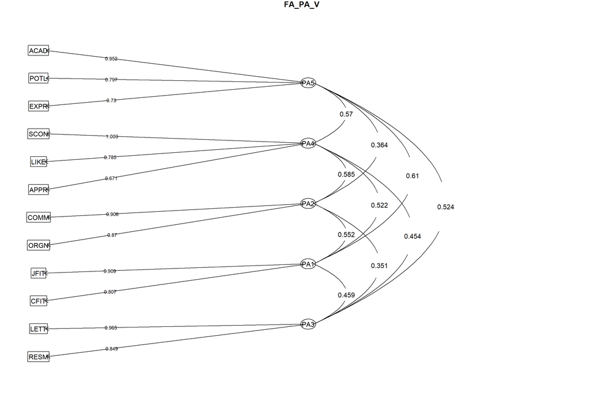

```r
##################################
# Graph the factor loading matrices
##################################
fa.diagram(FA_PA_P_5F,
           sort=TRUE,
           cut=0,
           digits=3,
           main="FA_PA_V",
           cex=0.75)
```

```r
##################################
# computing the internal consistency
# measure of reliability using the
# Cronbach's alpha coefficient
# for each factor
##################################
alpha(DPA.Descriptors.Numeric[,c("ACAD","POTL","EXPR")])
```

```
##
## Reliability analysis
## Call: alpha(x = DPA.Descriptors.Numeric[, c("ACAD", "POTL", "EXPR")])
##
##   raw_alpha std.alpha G6(smc) average_r S/N   ase mean  sd median_r
##       0.89      0.89    0.85      0.72 7.8 0.028  7.3 1.2      0.7
##
##     95% confidence boundaries
##          lower alpha upper
## Feldt     0.82  0.89  0.93
## Duhachek  0.83  0.89  0.94
##
##  Reliability if an item is dropped:
##      raw_alpha std.alpha G6(smc) average_r S/N alpha se var.r med.r
## ACAD      0.83      0.83    0.70      0.70 4.7    0.049    NA  0.70
## POTL      0.80      0.80    0.67      0.67 4.0    0.056    NA  0.67
## EXPR      0.88      0.89    0.80      0.80 7.8    0.032    NA  0.80
##
##  Item statistics
##       n raw.r std.r r.cor r.drop mean  sd
## ACAD 50  0.91  0.91  0.85   0.79  7.4 1.3
## POTL 50  0.92  0.92  0.88   0.82  7.3 1.4
## EXPR 50  0.88  0.88  0.76   0.72  7.3 1.4
##
## Non missing response frequency for each item
##         4    5    6    7    8    9   10 miss
## ACAD 0.02 0.02 0.22 0.28 0.24 0.18 0.04    0
## POTL 0.04 0.06 0.18 0.22 0.30 0.18 0.02    0
## EXPR 0.00 0.10 0.20 0.24 0.24 0.18 0.04    0
```

```r
alpha(DPA.Descriptors.Numeric[,c("SCON","LIKE","APPR")])
```

```
##
## Reliability analysis
## Call: alpha(x = DPA.Descriptors.Numeric[, c("SCON", "LIKE", "APPR")])
##
##   raw_alpha std.alpha G6(smc) average_r S/N   ase mean   sd median_r
##       0.87      0.87    0.83       0.7 6.9 0.031  7.4 0.99      0.7
##
##     95% confidence boundaries
##          lower alpha upper
## Feldt     0.80  0.87  0.92
## Duhachek  0.81  0.87  0.93
##
##  Reliability if an item is dropped:
##      raw_alpha std.alpha G6(smc) average_r S/N alpha se var.r med.r
## SCON      0.78      0.78    0.64      0.64 3.5    0.062    NA  0.64
## LIKE      0.82      0.82    0.70      0.70 4.6    0.051    NA  0.70
## APPR      0.86      0.86    0.75      0.75 6.1    0.040    NA  0.75
##
##  Item statistics
##       n raw.r std.r r.cor r.drop mean  sd
## SCON 50  0.92  0.91  0.86   0.80  7.3 1.2
## LIKE 50  0.90  0.89  0.82   0.76  7.4 1.1
## APPR 50  0.86  0.87  0.76   0.71  7.4 1.0
##
## Non missing response frequency for each item
##         4    5    6    7    8    9   10 miss
## SCON 0.00 0.08 0.14 0.32 0.28 0.18 0.00    0
## LIKE 0.02 0.04 0.12 0.32 0.36 0.14 0.00    0
## APPR 0.00 0.02 0.16 0.32 0.38 0.10 0.02    0
```

```r
alpha(DPA.Descriptors.Numeric[,c("COMM","ORGN")])
```

```
##
## Reliability analysis
## Call: alpha(x = DPA.Descriptors.Numeric[, c("COMM", "ORGN")])
##
##   raw_alpha std.alpha G6(smc) average_r S/N   ase mean  sd median_r
##       0.92      0.93    0.86      0.86  12 0.021  6.9 1.5     0.86
##
##     95% confidence boundaries
##          lower alpha upper
## Feldt     0.87  0.92  0.96
## Duhachek  0.88  0.92  0.97
##
##  Reliability if an item is dropped:
##      raw_alpha std.alpha G6(smc) average_r S/N alpha se var.r med.r
## COMM      0.80      0.86    0.74      0.86 6.2       NA     0  0.86
## ORGN      0.92      0.86    0.74      0.86 6.2       NA     0  0.86
##
##  Item statistics
##       n raw.r std.r r.cor r.drop mean  sd
## COMM 50  0.96  0.96   0.9   0.86  6.9 1.5
## ORGN 50  0.97  0.96   0.9   0.86  6.9 1.6
##
## Non missing response frequency for each item
##         3    4    5   6    7    8    9   10 miss
## COMM 0.04 0.04 0.06 0.2 0.30 0.28 0.06 0.02    0
## ORGN 0.02 0.04 0.20 0.1 0.24 0.24 0.16 0.00    0
```

```r
alpha(DPA.Descriptors.Numeric[,c("LETT","RESM")])
```

```
##
## Reliability analysis
## Call: alpha(x = DPA.Descriptors.Numeric[, c("LETT", "RESM")])
##
##   raw_alpha std.alpha G6(smc) average_r S/N   ase mean  sd median_r
##       0.91      0.91    0.84      0.84  10 0.025  7.2 1.6     0.84
##
##     95% confidence boundaries
##          lower alpha upper
## Feldt     0.84  0.91  0.95
## Duhachek  0.86  0.91  0.96
##
##  Reliability if an item is dropped:
##      raw_alpha std.alpha G6(smc) average_r S/N alpha se var.r med.r
## LETT      0.83      0.84     0.7      0.84 5.1       NA     0  0.84
## RESM      0.84      0.84     0.7      0.84 5.1       NA     0  0.84
##
##  Item statistics
##       n raw.r std.r r.cor r.drop mean  sd
## LETT 50  0.96  0.96  0.88   0.84  7.2 1.7
## RESM 50  0.96  0.96  0.88   0.84  7.2 1.7
##
## Non missing response frequency for each item
##         4    5    6    7    8    9   10 miss
## LETT 0.06 0.12 0.14 0.22 0.24 0.12 0.10    0
## RESM 0.08 0.06 0.22 0.18 0.16 0.24 0.06    0
```

```r
alpha(DPA.Descriptors.Numeric[,c("JFIT","CFIT")])
```

```
##
## Reliability analysis
## Call: alpha(x = DPA.Descriptors.Numeric[, c("JFIT", "CFIT")])
##
##   raw_alpha std.alpha G6(smc) average_r S/N   ase mean  sd median_r
##       0.94      0.94    0.88      0.88  15 0.018    7 1.6     0.88
##
##     95% confidence boundaries
##          lower alpha upper
## Feldt     0.89  0.94  0.96
## Duhachek  0.90  0.94  0.97
##
##  Reliability if an item is dropped:
##      raw_alpha std.alpha G6(smc) average_r S/N alpha se var.r med.r
## JFIT      0.87      0.88    0.78      0.88 7.5       NA     0  0.88
## CFIT      0.90      0.88    0.78      0.88 7.5       NA     0  0.88
##
##  Item statistics
##       n raw.r std.r r.cor r.drop mean  sd
## JFIT 50  0.97  0.97  0.91   0.88  7.0 1.6
## CFIT 50  0.97  0.97  0.91   0.88  6.9 1.6
##
## Non missing response frequency for each item
##         3    4    5    6    7    8    9   10 miss
## JFIT 0.06 0.00 0.06 0.22 0.26 0.24 0.12 0.04    0
## CFIT 0.02 0.06 0.16 0.12 0.22 0.30 0.08 0.04    0
```

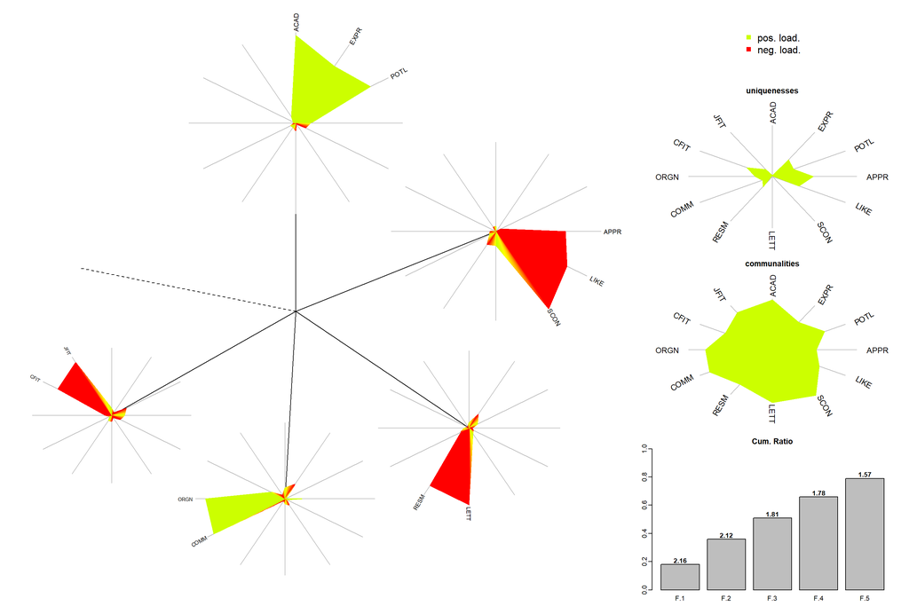

```r
##################################
# Formulating the dandelion plot to
# visualize both factor variances and loadings
# from the factor loading matrices
##################################
FA_PA_P_5F_FactorLoading <- factload(DPA.Descriptors.Numeric,
                                  cormeth = "pearson",
                                  method = "prax",
                                  nfac = 5,
                                  rotation = "promax")

DandelionPlotPalette <- rev(rainbow(100, start = 0, end = 0.2))

dandelion(FA_PA_P_5F_FactorLoading,
          bound=0,
          mcex=c(1,1.2),
          palet=DandelionPlotPalette)
```

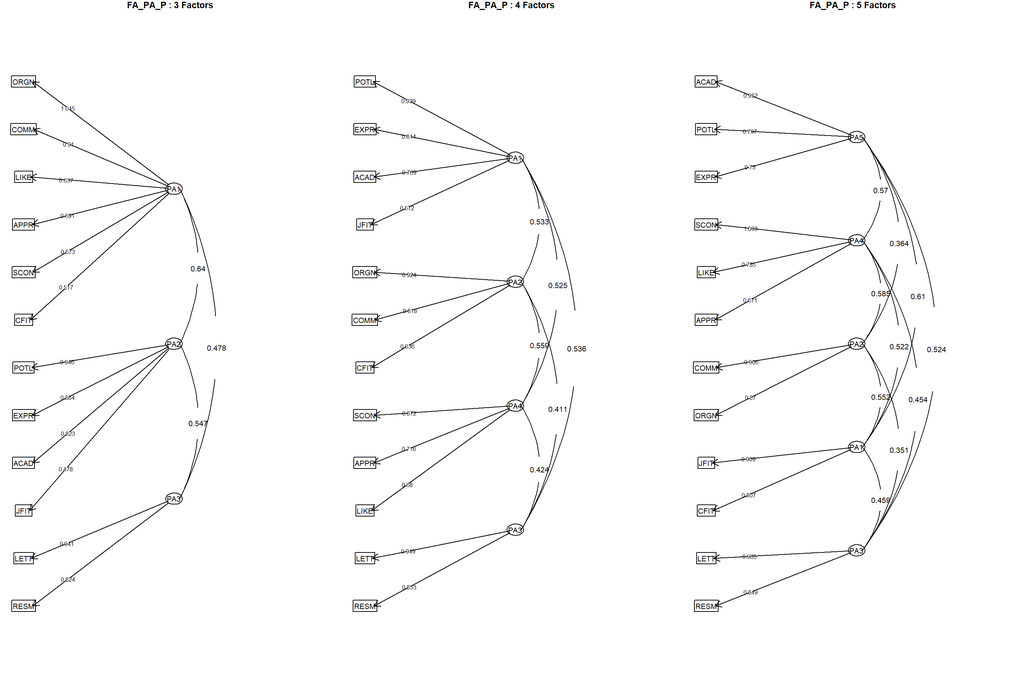

```r
par(mfrow=c(1,3))
fa.diagram(FA_PA_P_3F,
           sort=TRUE,
           cut=0,
           digits=3,
           main="FA_PA_P : 3 Factors",
           cex=0.75)
fa.diagram(FA_PA_P_4F,
           sort=TRUE,
           cut=0,
           digits=3,
           main="FA_PA_P : 4 Factors",
           cex=0.75)
fa.diagram(FA_PA_P_5F,
           sort=TRUE,
           cut=0,
           digits=3,
           main="FA_PA_P : 5 Factors",
           cex=0.75)
```

### 1.6.3 Maximum Likelihood Factor Extraction and Varimax Rotation (FA_ML_V)

**Code Chunk | Output**

```r
##################################
# Conducting exploratory factor analysis
# using Maximum Likelihood extraction
# and Varimax rotation
# with 3 factors
##################################
(FA_ML_V_3F <- fa(DPA.Descriptors.Numeric,
              nfactors = 3,
              fm="ml",
              rotate = "varimax",
              residuals=TRUE,
              SMC=TRUE,
              n.obs=nrow(DPA.Descriptors.Numeric)))
```

```
## Factor Analysis using method =  ml
## Call: fa(r = DPA.Descriptors.Numeric, nfactors = 3, n.obs = nrow(DPA.Descriptors.Numeric),
##     rotate = "varimax", residuals = TRUE, SMC = TRUE, fm = "ml")
## Standardized loadings (pattern matrix) based upon correlation matrix
##       ML3  ML2  ML1   h2    u2 com
## ACAD 0.76 0.24 0.20 0.67 0.326 1.3
## APPR 0.36 0.48 0.32 0.46 0.543 2.7
## COMM 0.16 0.85 0.23 0.80 0.203 1.2
## CFIT 0.53 0.56 0.19 0.62 0.377 2.2
## EXPR 0.71 0.04 0.32 0.61 0.385 1.4
## JFIT 0.62 0.45 0.21 0.62 0.379 2.1
## LETT 0.22 0.25 0.78 0.71 0.289 1.4
## LIKE 0.35 0.48 0.29 0.44 0.563 2.6
## ORGN 0.15 0.96 0.07 0.96 0.043 1.1
## POTL 0.90 0.29 0.14 0.92 0.079 1.3
## RESM 0.30 0.19 0.93 1.00 0.005 1.3
## SCON 0.39 0.43 0.25 0.40 0.597 2.6
##
##                        ML3  ML2  ML1
## SS loadings           3.15 3.04 2.02
## Proportion Var        0.26 0.25 0.17
## Cumulative Var        0.26 0.52 0.68
## Proportion Explained  0.38 0.37 0.25
## Cumulative Proportion 0.38 0.75 1.00
##
## Mean item complexity =  1.8
## Test of the hypothesis that 3 factors are sufficient.
##
## The degrees of freedom for the null model are  66  and the objective function was  10.7 with Chi Square of  472.51
## The degrees of freedom for the model are 33  and the objective function was  2.22
##
## The root mean square of the residuals (RMSR) is  0.08
## The df corrected root mean square of the residuals is  0.11
##
## The harmonic number of observations is  50 with the empirical chi square  41.84  with prob <  0.14
## The total number of observations was  50  with Likelihood Chi Square =  93.49  with prob <  1.1e-07
##
## Tucker Lewis Index of factoring reliability =  0.686
## RMSEA index =  0.19  and the 90 % confidence intervals are  0.148 0.24
## BIC =  -35.6
## Fit based upon off diagonal values = 0.98
## Measures of factor score adequacy
##                                                    ML3  ML2  ML1
## Correlation of (regression) scores with factors   0.96 0.98 0.99
## Multiple R square of scores with factors          0.92 0.96 0.99
## Minimum correlation of possible factor scores     0.84 0.92 0.97
```

```r
(FA_ML_V_3F_Summary <- FA_ML_V_3F %>%
  model_parameters(sort = TRUE, threshold = "max"))
```

```
## # Rotated loadings from Factor Analysis (varimax-rotation)
##
## Variable | ML3  | ML2  | ML1  | Complexity | Uniqueness
## -------------------------------------------------------
## POTL     | 0.90 |      |      |    1.25    |    0.08
## ACAD     | 0.76 |      |      |    1.35    |    0.33
## EXPR     | 0.71 |      |      |    1.39    |    0.39
## JFIT     | 0.62 |      |      |    2.09    |    0.38
## ORGN     |      | 0.96 |      |    1.06    |    0.04
## COMM     |      | 0.85 |      |    1.22    |    0.20
## CFIT     |      | 0.56 |      |    2.24    |    0.38
## LIKE     |      | 0.48 |      |    2.56    |    0.56
## APPR     |      | 0.48 |      |    2.67    |    0.54
## SCON     |      | 0.43 |      |    2.60    |    0.60
## RESM     |      |      | 0.93 |    1.29    |  4.98e-03
## LETT     |      |      | 0.78 |    1.38    |    0.29
##
## The 3 latent factors (varimax rotation) accounted for 68.42% of the total variance of the original data (ML3 = 26.22%, ML2 = 25.33%, ML1 = 16.87%).
```

```r
summary(FA_ML_V_3F_Summary)
```

```
## # (Explained) Variance of Components
##
## Parameter                       |   ML3 |   ML2 |   ML1
## -------------------------------------------------------
## Eigenvalues                     | 6.079 | 1.261 | 0.922
## Variance Explained              | 0.262 | 0.253 | 0.169
## Variance Explained (Cumulative) | 0.262 | 0.515 | 0.684
## Variance Explained (Proportion) | 0.383 | 0.370 | 0.247
```

```r
##################################
# Extracting the residuals
# from the Exploratory Factor Analysis
##################################
(FA_ML_V_3F_Residual <- residuals(FA_ML_V_3F,
                              diag=FALSE,
                              na.rm=TRUE))
```

```
##      ACAD  APPR  COMM  CFIT  EXPR  JFIT  LETT  LIKE  ORGN  POTL  RESM
## ACAD    NA
## APPR  0.02    NA
## COMM  0.04 -0.04    NA
## CFIT -0.07 -0.10 -0.01    NA
## EXPR  0.05 -0.07 -0.02 -0.06    NA
## JFIT -0.08 -0.09 -0.02  0.27  0.00    NA
## LETT -0.06 -0.14 -0.02  0.05  0.06  0.06    NA
## LIKE -0.04  0.19 -0.04 -0.02 -0.06  0.04 -0.06    NA
## ORGN  0.00  0.00  0.00 -0.01  0.01 -0.01  0.01 -0.01    NA
## POTL  0.01  0.01  0.00  0.00  0.00 -0.01  0.00 -0.01  0.00    NA
## RESM  0.00  0.00  0.00  0.00  0.00  0.00  0.00  0.00  0.00  0.00    NA
## SCON -0.04  0.27 -0.05 -0.03  0.03 -0.02 -0.15  0.34  0.00 -0.01  0.00
## [1]    NA
```

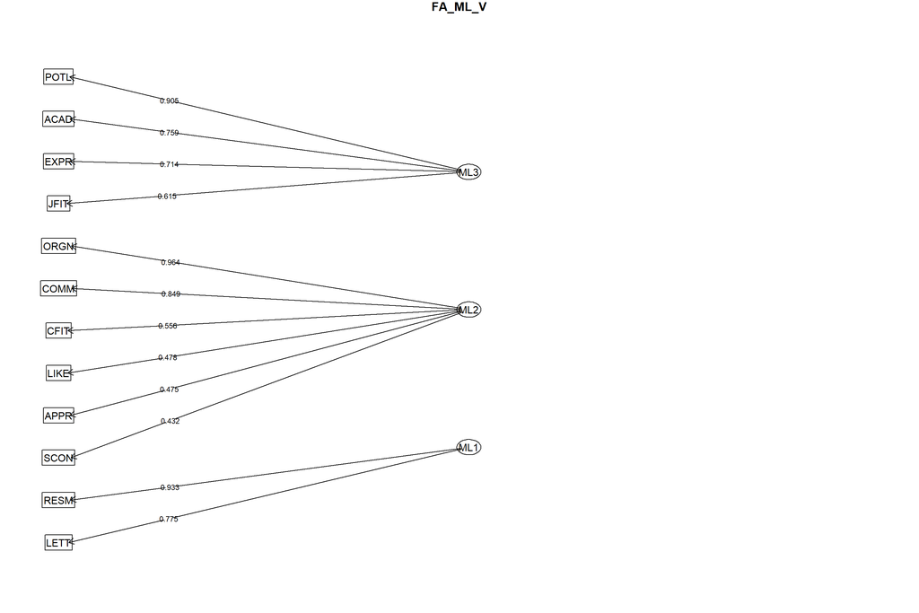

```r
##################################
# Graph the factor loading matrices
##################################
fa.diagram(FA_ML_V_3F,
           sort=TRUE,
           cut=0,
           digits=3,
           main="FA_ML_V",
           cex=0.75)
```

```r
##################################
# computing the internal consistency
# measure of reliability using the
# Cronbach's alpha coefficient
# for each factor
##################################
alpha(DPA.Descriptors.Numeric[,c("POTL","ACAD","EXPR","JFIT")])
```

```
##
## Reliability analysis
## Call: alpha(x = DPA.Descriptors.Numeric[, c("POTL", "ACAD", "EXPR",
##     "JFIT")])
##
##   raw_alpha std.alpha G6(smc) average_r S/N   ase mean  sd median_r
##       0.88      0.88    0.87      0.66 7.6 0.028  7.3 1.2     0.69
##
##     95% confidence boundaries
##          lower alpha upper
## Feldt     0.81  0.88  0.93
## Duhachek  0.82  0.88  0.93
##
##  Reliability if an item is dropped:
##      raw_alpha std.alpha G6(smc) average_r S/N alpha se  var.r med.r
## POTL      0.79      0.80    0.74      0.58 4.1    0.051 0.0063  0.54
## ACAD      0.84      0.84    0.80      0.64 5.4    0.040 0.0111  0.70
## EXPR      0.86      0.86    0.84      0.68 6.4    0.036 0.0169  0.71
## JFIT      0.89      0.89    0.85      0.72 7.8    0.028 0.0043  0.70
##
##  Item statistics
##       n raw.r std.r r.cor r.drop mean  sd
## POTL 50  0.93  0.93  0.92   0.87  7.3 1.4
## ACAD 50  0.86  0.87  0.83   0.76  7.4 1.3
## EXPR 50  0.83  0.84  0.75   0.71  7.3 1.4
## JFIT 50  0.82  0.80  0.71   0.65  7.0 1.6
##
## Non missing response frequency for each item
##         3    4    5    6    7    8    9   10 miss
## POTL 0.00 0.04 0.06 0.18 0.22 0.30 0.18 0.02    0
## ACAD 0.00 0.02 0.02 0.22 0.28 0.24 0.18 0.04    0
## EXPR 0.00 0.00 0.10 0.20 0.24 0.24 0.18 0.04    0
## JFIT 0.06 0.00 0.06 0.22 0.26 0.24 0.12 0.04    0
```

```r
alpha(DPA.Descriptors.Numeric[,c("ORGN","COMM","LIKE","APPR","SCON","CFIT")])
```

```
##
## Reliability analysis
## Call: alpha(x = DPA.Descriptors.Numeric[, c("ORGN", "COMM", "LIKE",
##     "APPR", "SCON", "CFIT")])
##
##   raw_alpha std.alpha G6(smc) average_r S/N   ase mean  sd median_r
##       0.88      0.89     0.9      0.57 7.8 0.026  7.1 1.1     0.53
##
##     95% confidence boundaries
##          lower alpha upper
## Feldt     0.82  0.88  0.92
## Duhachek  0.83  0.88  0.93
##
##  Reliability if an item is dropped:
##      raw_alpha std.alpha G6(smc) average_r S/N alpha se var.r med.r
## ORGN      0.84      0.86    0.85      0.55 6.0    0.036 0.014  0.49
## COMM      0.85      0.87    0.86      0.56 6.4    0.034 0.012  0.53
## LIKE      0.86      0.86    0.88      0.56 6.4    0.030 0.019  0.52
## APPR      0.86      0.87    0.89      0.57 6.7    0.030 0.019  0.51
## SCON      0.86      0.87    0.87      0.57 6.5    0.029 0.015  0.53
## CFIT      0.87      0.88    0.90      0.59 7.3    0.029 0.020  0.53
##
##  Item statistics
##       n raw.r std.r r.cor r.drop mean  sd
## ORGN 50  0.87  0.84  0.84   0.78  6.9 1.6
## COMM 50  0.84  0.81  0.79   0.74  6.9 1.5
## LIKE 50  0.78  0.81  0.77   0.69  7.4 1.1
## APPR 50  0.75  0.79  0.73   0.67  7.4 1.0
## SCON 50  0.76  0.80  0.76   0.67  7.3 1.2
## CFIT 50  0.78  0.75  0.66   0.64  6.9 1.6
##
## Non missing response frequency for each item
##         3    4    5    6    7    8    9   10 miss
## ORGN 0.02 0.04 0.20 0.10 0.24 0.24 0.16 0.00    0
## COMM 0.04 0.04 0.06 0.20 0.30 0.28 0.06 0.02    0
## LIKE 0.00 0.02 0.04 0.12 0.32 0.36 0.14 0.00    0
## APPR 0.00 0.00 0.02 0.16 0.32 0.38 0.10 0.02    0
## SCON 0.00 0.00 0.08 0.14 0.32 0.28 0.18 0.00    0
## CFIT 0.02 0.06 0.16 0.12 0.22 0.30 0.08 0.04    0
```

```r
alpha(DPA.Descriptors.Numeric[,c("RESM","LETT")])
```

```
##
## Reliability analysis
## Call: alpha(x = DPA.Descriptors.Numeric[, c("RESM", "LETT")])
##
##   raw_alpha std.alpha G6(smc) average_r S/N   ase mean  sd median_r
##       0.91      0.91    0.84      0.84  10 0.025  7.2 1.6     0.84
##
##     95% confidence boundaries
##          lower alpha upper
## Feldt     0.84  0.91  0.95
## Duhachek  0.86  0.91  0.96
##
##  Reliability if an item is dropped:
##      raw_alpha std.alpha G6(smc) average_r S/N alpha se var.r med.r
## RESM      0.84      0.84     0.7      0.84 5.1       NA     0  0.84
## LETT      0.83      0.84     0.7      0.84 5.1       NA     0  0.84
##
##  Item statistics
##       n raw.r std.r r.cor r.drop mean  sd
## RESM 50  0.96  0.96  0.88   0.84  7.2 1.7
## LETT 50  0.96  0.96  0.88   0.84  7.2 1.7
##
## Non missing response frequency for each item
##         4    5    6    7    8    9   10 miss
## RESM 0.08 0.06 0.22 0.18 0.16 0.24 0.06    0
## LETT 0.06 0.12 0.14 0.22 0.24 0.12 0.10    0
```

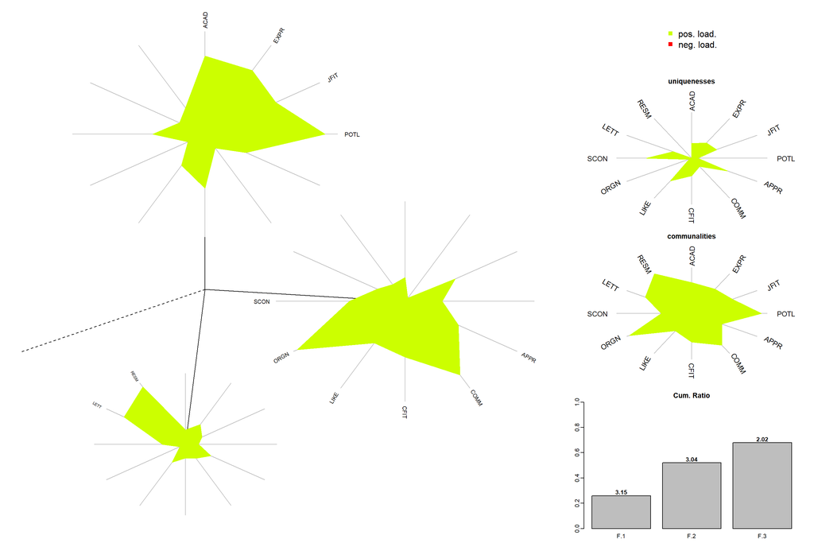

```r
##################################
# Formulating the dandelion plot to
# visualize both factor variances and loadings
# from the factor loading matrices
##################################
FA_ML_V_3F_FactorLoading <- factload(DPA.Descriptors.Numeric,
                                  cormeth = "pearson",
                                  method = "mle",
                                  nfac = 3,
                                  rotation = "varimax")

DandelionPlotPalette <- rev(rainbow(100, start = 0, end = 0.2))

dandelion(FA_ML_V_3F_FactorLoading,
          bound=0,
          mcex=c(1,1.2),
          palet=DandelionPlotPalette)
```

```r
##################################
# Conducting exploratory factor analysis
# using Maximum Likelihood extraction
# and Varimax rotation
# with 4 factors
##################################
(FA_ML_V_4F <- fa(DPA.Descriptors.Numeric,
              nfactors = 4,
              fm="ml",
              rotate = "varimax",
              residuals=TRUE,
              SMC=TRUE,
              n.obs=nrow(DPA.Descriptors.Numeric)))
```

```
## Factor Analysis using method =  ml
## Call: fa(r = DPA.Descriptors.Numeric, nfactors = 4, n.obs = nrow(DPA.Descriptors.Numeric),
##     rotate = "varimax", residuals = TRUE, SMC = TRUE, fm = "ml")
## Standardized loadings (pattern matrix) based upon correlation matrix
##       ML3  ML4   ML2  ML1   h2    u2 com
## ACAD 0.49 0.38  0.12 0.24 0.45 0.546 2.5
## APPR 0.18 0.72  0.29 0.22 0.68 0.325 1.7
## COMM 0.21 0.26  0.79 0.23 0.79 0.206 1.6
## CFIT 0.78 0.16  0.42 0.19 0.85 0.148 1.8
## EXPR 0.50 0.30 -0.07 0.35 0.46 0.535 2.6
## JFIT 0.87 0.19  0.29 0.19 0.91 0.089 1.4
## LETT 0.27 0.06  0.22 0.81 0.78 0.224 1.4
## LIKE 0.31 0.67  0.27 0.17 0.65 0.350 1.9
## ORGN 0.23 0.30  0.91 0.06 0.97 0.027 1.4
## POTL 0.66 0.40  0.15 0.18 0.65 0.347 1.9
## RESM 0.22 0.33  0.10 0.91 1.00 0.005 1.4
## SCON 0.27 0.81  0.19 0.10 0.78 0.220 1.4
##
##                        ML3  ML4  ML2  ML1
## SS loadings           2.71 2.36 2.00 1.91
## Proportion Var        0.23 0.20 0.17 0.16
## Cumulative Var        0.23 0.42 0.59 0.75
## Proportion Explained  0.30 0.26 0.22 0.21
## Cumulative Proportion 0.30 0.56 0.79 1.00
##
## Mean item complexity =  1.7
## Test of the hypothesis that 4 factors are sufficient.
##
## The degrees of freedom for the null model are  66  and the objective function was  10.7 with Chi Square of  472.51
## The degrees of freedom for the model are 24  and the objective function was  1.36
##
## The root mean square of the residuals (RMSR) is  0.06
## The df corrected root mean square of the residuals is  0.1
##
## The harmonic number of observations is  50 with the empirical chi square  22.17  with prob <  0.57
## The total number of observations was  50  with Likelihood Chi Square =  56.38  with prob <  2e-04
##
## Tucker Lewis Index of factoring reliability =  0.764
## RMSEA index =  0.163  and the 90 % confidence intervals are  0.11 0.223
## BIC =  -37.51
## Fit based upon off diagonal values = 0.99
## Measures of factor score adequacy
##                                                    ML3  ML4  ML2  ML1
## Correlation of (regression) scores with factors   0.95 0.91 0.97 0.99
## Multiple R square of scores with factors          0.91 0.83 0.95 0.98
## Minimum correlation of possible factor scores     0.82 0.65 0.90 0.95
```

```r
(FA_ML_V_4F_Summary <- FA_ML_V_4F %>%
  model_parameters(sort = TRUE, threshold = "max"))
```

```
## # Rotated loadings from Factor Analysis (varimax-rotation)
##
## Variable | ML3  | ML4  | ML2  | ML1  | Complexity | Uniqueness
## --------------------------------------------------------------
## JFIT     | 0.87 |      |      |      |    1.43    |    0.09
## CFIT     | 0.78 |      |      |      |    1.79    |    0.15
## POTL     | 0.66 |      |      |      |    1.94    |    0.35
## EXPR     | 0.50 |      |      |      |    2.56    |    0.54
## ACAD     | 0.49 |      |      |      |    2.54    |    0.55
## SCON     |      | 0.81 |      |      |    1.37    |    0.22
## APPR     |      | 0.72 |      |      |    1.66    |    0.32
## LIKE     |      | 0.67 |      |      |    1.90    |    0.35
## ORGN     |      |      | 0.91 |      |    1.37    |    0.03
## COMM     |      |      | 0.79 |      |    1.58    |    0.21
## RESM     |      |      |      | 0.91 |    1.41    |  5.00e-03
## LETT     |      |      |      | 0.81 |    1.39    |    0.22
##
## The 4 latent factors (varimax rotation) accounted for 74.82% of the total variance of the original data (ML3 = 22.58%, ML4 = 19.64%, ML2 = 16.70%, ML1 = 15.90%).
```

```r
summary(FA_ML_V_4F_Summary)
```

```
## # (Explained) Variance of Components
##
## Parameter                       |   ML3 |   ML4 |   ML2 |   ML1
## ---------------------------------------------------------------
## Eigenvalues                     | 6.146 | 1.248 | 0.890 | 0.846
## Variance Explained              | 0.226 | 0.196 | 0.167 | 0.159
## Variance Explained (Cumulative) | 0.226 | 0.422 | 0.589 | 0.748
## Variance Explained (Proportion) | 0.302 | 0.263 | 0.223 | 0.212
```

```r
##################################
# Extracting the residuals
# from the Exploratory Factor Analysis
##################################
(FA_ML_V_4F_Residual <- residuals(FA_ML_V_4F,
                              diag=FALSE,
                              na.rm=TRUE))
```

```
##      ACAD  APPR  COMM  CFIT  EXPR  JFIT  LETT  LIKE  ORGN  POTL  RESM
## ACAD    NA
## APPR  0.03    NA
## COMM  0.05 -0.01    NA
## CFIT -0.04  0.00  0.00    NA
## EXPR  0.24 -0.05 -0.02 -0.08    NA
## JFIT -0.04  0.00  0.00  0.01 -0.01    NA
## LETT -0.04 -0.03 -0.03 -0.01  0.06  0.00    NA
## LIKE -0.08 -0.01  0.00 -0.01 -0.09  0.03  0.04    NA
## ORGN  0.00  0.00  0.00  0.00  0.01  0.00  0.01  0.00    NA
## POTL  0.26  0.03  0.02 -0.02  0.20 -0.02  0.00 -0.05  0.00    NA
## RESM  0.00  0.00  0.00  0.00  0.00  0.00  0.00  0.00  0.00  0.00    NA
## SCON -0.08 -0.01 -0.01  0.02  0.00  0.00 -0.01  0.05  0.00 -0.05  0.00
## [1]    NA
```

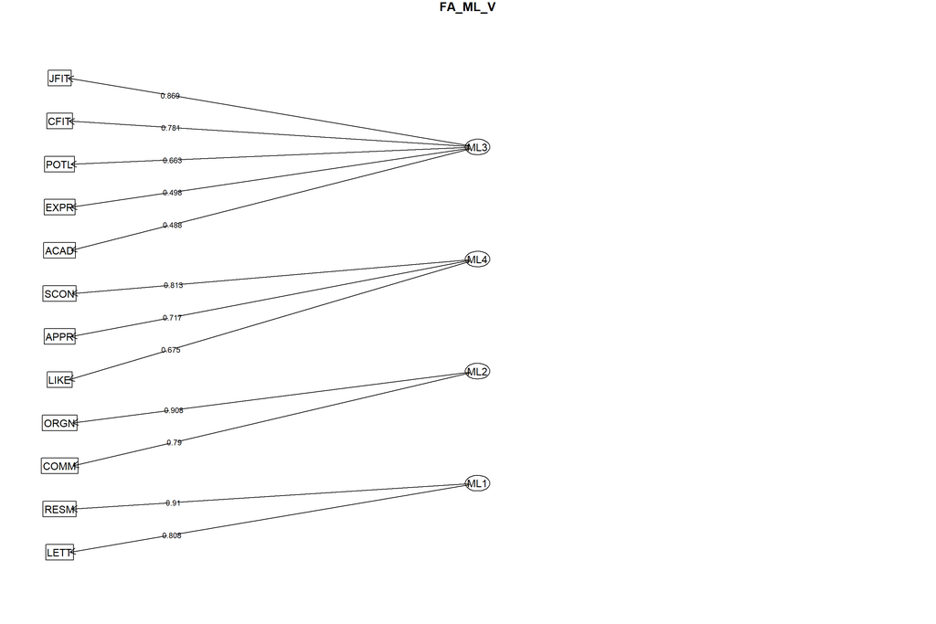

```r
##################################
# Graph the factor loading matrices
##################################
fa.diagram(FA_ML_V_4F,
           sort=TRUE,
           cut=0,
           digits=3,
           main="FA_ML_V",
           cex=0.75)
```

```r
##################################
# computing the internal consistency
# measure of reliability using the
# Cronbach's alpha coefficient
# for each factor
##################################
alpha(DPA.Descriptors.Numeric[,c("JFIT","CFIT","POTL","EXPR","ACAD")])
```

```
##
## Reliability analysis
## Call: alpha(x = DPA.Descriptors.Numeric[, c("JFIT", "CFIT", "POTL",
##     "EXPR", "ACAD")])
##
##   raw_alpha std.alpha G6(smc) average_r S/N   ase mean  sd median_r
##        0.9       0.9    0.92      0.64 8.8 0.024  7.2 1.2     0.66
##
##     95% confidence boundaries
##          lower alpha upper
## Feldt     0.84   0.9  0.94
## Duhachek  0.85   0.9  0.94
##
##  Reliability if an item is dropped:
##      raw_alpha std.alpha G6(smc) average_r S/N alpha se var.r med.r
## JFIT      0.86      0.87    0.86      0.62 6.5    0.034 0.021  0.66
## CFIT      0.88      0.88    0.87      0.66 7.6    0.028 0.011  0.69
## POTL      0.85      0.85    0.88      0.58 5.6    0.036 0.029  0.53
## EXPR      0.89      0.89    0.91      0.68 8.5    0.025 0.022  0.68
## ACAD      0.88      0.88    0.90      0.64 7.3    0.029 0.028  0.68
##
##  Item statistics
##       n raw.r std.r r.cor r.drop mean  sd
## JFIT 50  0.88  0.87  0.86   0.80  7.0 1.6
## CFIT 50  0.84  0.82  0.80   0.72  6.9 1.6
## POTL 50  0.91  0.92  0.90   0.85  7.3 1.4
## EXPR 50  0.76  0.78  0.71   0.64  7.3 1.4
## ACAD 50  0.81  0.83  0.78   0.72  7.4 1.3
##
## Non missing response frequency for each item
##         3    4    5    6    7    8    9   10 miss
## JFIT 0.06 0.00 0.06 0.22 0.26 0.24 0.12 0.04    0
## CFIT 0.02 0.06 0.16 0.12 0.22 0.30 0.08 0.04    0
## POTL 0.00 0.04 0.06 0.18 0.22 0.30 0.18 0.02    0
## EXPR 0.00 0.00 0.10 0.20 0.24 0.24 0.18 0.04    0
## ACAD 0.00 0.02 0.02 0.22 0.28 0.24 0.18 0.04    0
```

```r
alpha(DPA.Descriptors.Numeric[,c("SCON","APPR","LIKE")])
```

```
##
## Reliability analysis
## Call: alpha(x = DPA.Descriptors.Numeric[, c("SCON", "APPR", "LIKE")])
##
##   raw_alpha std.alpha G6(smc) average_r S/N   ase mean   sd median_r
##       0.87      0.87    0.83       0.7 6.9 0.031  7.4 0.99      0.7
##
##     95% confidence boundaries
##          lower alpha upper
## Feldt     0.80  0.87  0.92
## Duhachek  0.81  0.87  0.93
##
##  Reliability if an item is dropped:
##      raw_alpha std.alpha G6(smc) average_r S/N alpha se var.r med.r
## SCON      0.78      0.78    0.64      0.64 3.5    0.062    NA  0.64
## APPR      0.86      0.86    0.75      0.75 6.1    0.040    NA  0.75
## LIKE      0.82      0.82    0.70      0.70 4.6    0.051    NA  0.70
##
##  Item statistics
##       n raw.r std.r r.cor r.drop mean  sd
## SCON 50  0.92  0.91  0.86   0.80  7.3 1.2
## APPR 50  0.86  0.87  0.76   0.71  7.4 1.0
## LIKE 50  0.90  0.89  0.82   0.76  7.4 1.1
##
## Non missing response frequency for each item
##         4    5    6    7    8    9   10 miss
## SCON 0.00 0.08 0.14 0.32 0.28 0.18 0.00    0
## APPR 0.00 0.02 0.16 0.32 0.38 0.10 0.02    0
## LIKE 0.02 0.04 0.12 0.32 0.36 0.14 0.00    0
```

```r
alpha(DPA.Descriptors.Numeric[,c("ORGN","COMM")])
```

```
##
## Reliability analysis
## Call: alpha(x = DPA.Descriptors.Numeric[, c("ORGN", "COMM")])
##
##   raw_alpha std.alpha G6(smc) average_r S/N   ase mean  sd median_r
##       0.92      0.93    0.86      0.86  12 0.021  6.9 1.5     0.86
##
##     95% confidence boundaries
##          lower alpha upper
## Feldt     0.87  0.92  0.96
## Duhachek  0.88  0.92  0.97
##
##  Reliability if an item is dropped:
##      raw_alpha std.alpha G6(smc) average_r S/N alpha se var.r med.r
## ORGN      0.92      0.86    0.74      0.86 6.2       NA     0  0.86
## COMM      0.80      0.86    0.74      0.86 6.2       NA     0  0.86
##
##  Item statistics
##       n raw.r std.r r.cor r.drop mean  sd
## ORGN 50  0.97  0.96   0.9   0.86  6.9 1.6
## COMM 50  0.96  0.96   0.9   0.86  6.9 1.5
##
## Non missing response frequency for each item
##         3    4    5   6    7    8    9   10 miss
## ORGN 0.02 0.04 0.20 0.1 0.24 0.24 0.16 0.00    0
## COMM 0.04 0.04 0.06 0.2 0.30 0.28 0.06 0.02    0
```

```r
alpha(DPA.Descriptors.Numeric[,c("RESM","LETT")])
```

```
##
## Reliability analysis
## Call: alpha(x = DPA.Descriptors.Numeric[, c("RESM", "LETT")])
##
##   raw_alpha std.alpha G6(smc) average_r S/N   ase mean  sd median_r
##       0.91      0.91    0.84      0.84  10 0.025  7.2 1.6     0.84
##
##     95% confidence boundaries
##          lower alpha upper
## Feldt     0.84  0.91  0.95
## Duhachek  0.86  0.91  0.96
##
##  Reliability if an item is dropped:
##      raw_alpha std.alpha G6(smc) average_r S/N alpha se var.r med.r
## RESM      0.84      0.84     0.7      0.84 5.1       NA     0  0.84
## LETT      0.83      0.84     0.7      0.84 5.1       NA     0  0.84
##
##  Item statistics
##       n raw.r std.r r.cor r.drop mean  sd
## RESM 50  0.96  0.96  0.88   0.84  7.2 1.7
## LETT 50  0.96  0.96  0.88   0.84  7.2 1.7
##
## Non missing response frequency for each item
##         4    5    6    7    8    9   10 miss
## RESM 0.08 0.06 0.22 0.18 0.16 0.24 0.06    0
## LETT 0.06 0.12 0.14 0.22 0.24 0.12 0.10    0
```

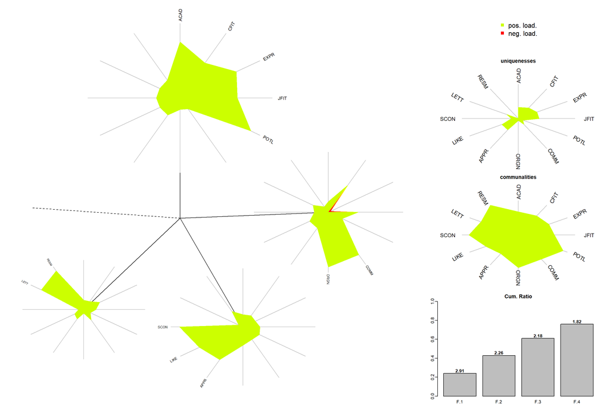

```r
##################################
# Formulating the dandelion plot to
# visualize both factor variances and loadings
# from the factor loading matrices
##################################
FA_ML_V_4F_FactorLoading <- factload(DPA.Descriptors.Numeric,
                                  cormeth = "pearson",
                                  method = "mle",
                                  nfac = 4,
                                  rotation = "varimax")

DandelionPlotPalette <- rev(rainbow(100, start = 0, end = 0.2))

dandelion(FA_ML_V_4F_FactorLoading,
          bound=0,
          mcex=c(1,1.2),
          palet=DandelionPlotPalette)
```

```r
##################################
# Conducting exploratory factor analysis
# using Maximum Likelihood extraction
# and Varimax rotation
# with 5 factors
##################################
(FA_ML_V_5F <- fa(DPA.Descriptors.Numeric,
              nfactors = 5,
              fm="ml",
              rotate = "varimax",
              residuals=TRUE,
              SMC=TRUE,
              n.obs=nrow(DPA.Descriptors.Numeric)))
```

```
## Factor Analysis using method =  ml
## Call: fa(r = DPA.Descriptors.Numeric, nfactors = 5, n.obs = nrow(DPA.Descriptors.Numeric),
##     rotate = "varimax", residuals = TRUE, SMC = TRUE, fm = "ml")
## Standardized loadings (pattern matrix) based upon correlation matrix
##       ML5  ML4   ML2  ML1  ML3   h2    u2 com
## ACAD 0.81 0.20  0.20 0.17 0.14 0.78 0.218 1.4
## APPR 0.28 0.65  0.31 0.21 0.05 0.65 0.353 2.1
## COMM 0.14 0.25  0.79 0.24 0.20 0.80 0.196 1.6
## CFIT 0.30 0.22  0.37 0.21 0.72 0.85 0.154 2.3
## EXPR 0.69 0.19 -0.04 0.29 0.20 0.64 0.362 1.7
## JFIT 0.37 0.23  0.23 0.21 0.81 0.95 0.050 1.9
## LETT 0.19 0.07  0.20 0.81 0.21 0.77 0.229 1.4
## LIKE 0.17 0.71  0.24 0.18 0.25 0.68 0.319 1.8
## ORGN 0.10 0.31  0.89 0.07 0.25 0.96 0.035 1.5
## POTL 0.79 0.27  0.18 0.12 0.35 0.87 0.132 1.8
## RESM 0.27 0.30  0.10 0.90 0.10 1.00 0.005 1.5
## SCON 0.22 0.87  0.17 0.09 0.16 0.87 0.130 1.3
##
##                        ML5  ML4  ML2  ML1  ML3
## SS loadings           2.29 2.18 1.92 1.82 1.61
## Proportion Var        0.19 0.18 0.16 0.15 0.13
## Cumulative Var        0.19 0.37 0.53 0.68 0.82
## Proportion Explained  0.23 0.22 0.20 0.19 0.16
## Cumulative Proportion 0.23 0.45 0.65 0.84 1.00
##
## Mean item complexity =  1.7
## Test of the hypothesis that 5 factors are sufficient.
##
## The degrees of freedom for the null model are  66  and the objective function was  10.7 with Chi Square of  472.51
## The degrees of freedom for the model are 16  and the objective function was  0.42
##
## The root mean square of the residuals (RMSR) is  0.02
## The df corrected root mean square of the residuals is  0.04
##
## The harmonic number of observations is  50 with the empirical chi square  2.44  with prob <  1
## The total number of observations was  50  with Likelihood Chi Square =  17.27  with prob <  0.37
##
## Tucker Lewis Index of factoring reliability =  0.986
## RMSEA index =  0.034  and the 90 % confidence intervals are  0 0.141
## BIC =  -45.32
## Fit based upon off diagonal values = 1
## Measures of factor score adequacy
##                                                    ML5  ML4  ML2  ML1  ML3
## Correlation of (regression) scores with factors   0.92 0.93 0.97 0.99 0.95
## Multiple R square of scores with factors          0.85 0.86 0.94 0.98 0.90
## Minimum correlation of possible factor scores     0.71 0.72 0.88 0.96 0.80
```

```r
(FA_ML_V_5F_Summary <- FA_ML_V_5F %>%
  model_parameters(sort = TRUE, threshold = "max"))
```

```
## # Rotated loadings from Factor Analysis (varimax-rotation)
##
## Variable | ML5  | ML4  | ML2  | ML1  | ML3  | Complexity | Uniqueness
## ---------------------------------------------------------------------
## ACAD     | 0.81 |      |      |      |      |    1.40    |    0.22
## POTL     | 0.79 |      |      |      |      |    1.84    |    0.13
## EXPR     | 0.69 |      |      |      |      |    1.71    |    0.36
## SCON     |      | 0.87 |      |      |      |    1.30    |    0.13
## LIKE     |      | 0.71 |      |      |      |    1.81    |    0.32
## APPR     |      | 0.65 |      |      |      |    2.14    |    0.35
## ORGN     |      |      | 0.89 |      |      |    1.45    |    0.04
## COMM     |      |      | 0.79 |      |      |    1.62    |    0.20
## RESM     |      |      |      | 0.90 |      |    1.47    |  4.99e-03
## LETT     |      |      |      | 0.81 |      |    1.40    |    0.23
## JFIT     |      |      |      |      | 0.81 |    1.94    |    0.05
## CFIT     |      |      |      |      | 0.72 |    2.34    |    0.15
##
## The 5 latent factors (varimax rotation) accounted for 81.81% of the total variance of the original data (ML5 = 19.05%, ML4 = 18.17%, ML2 = 15.99%, ML1 = 15.16%, ML3 = 13.44%).
```

```r
summary(FA_ML_V_5F_Summary)
```

```
## # (Explained) Variance of Components
##
## Parameter                       |   ML5 |   ML4 |   ML2 |   ML1 |   ML3
## -----------------------------------------------------------------------
## Eigenvalues                     | 6.215 | 1.301 | 0.958 | 0.877 | 0.477
## Variance Explained              | 0.190 | 0.182 | 0.160 | 0.152 | 0.134
## Variance Explained (Cumulative) | 0.190 | 0.372 | 0.532 | 0.684 | 0.818
## Variance Explained (Proportion) | 0.233 | 0.222 | 0.195 | 0.185 | 0.164
```

```r
##################################
# Extracting the residuals
# from the Exploratory Factor Analysis
##################################
(FA_ML_V_5F_Residual <- residuals(FA_ML_V_5F,
                              diag=FALSE,
                              na.rm=TRUE))
```

```
##      ACAD  APPR  COMM  CFIT  EXPR  JFIT  LETT  LIKE  ORGN  POTL  RESM
## ACAD    NA
## APPR  0.01    NA
## COMM  0.02 -0.01    NA
## CFIT  0.00  0.00  0.00    NA
## EXPR  0.00 -0.07 -0.03 -0.05    NA
## JFIT  0.00  0.00  0.00  0.00  0.01    NA
## LETT -0.04 -0.04 -0.03 -0.01  0.07  0.00    NA
## LIKE  0.01  0.01  0.01 -0.03 -0.04  0.01  0.03    NA
## ORGN  0.00  0.00  0.00  0.00  0.01  0.00  0.01  0.00    NA
## POTL  0.00  0.01  0.00  0.01  0.01  0.00  0.01  0.01  0.00    NA
## RESM  0.00  0.00  0.00  0.00  0.00  0.00  0.00  0.00  0.00  0.00    NA
## SCON -0.01 -0.01  0.00  0.01  0.04  0.00 -0.01  0.00  0.00  0.00  0.00
## [1]    NA
```

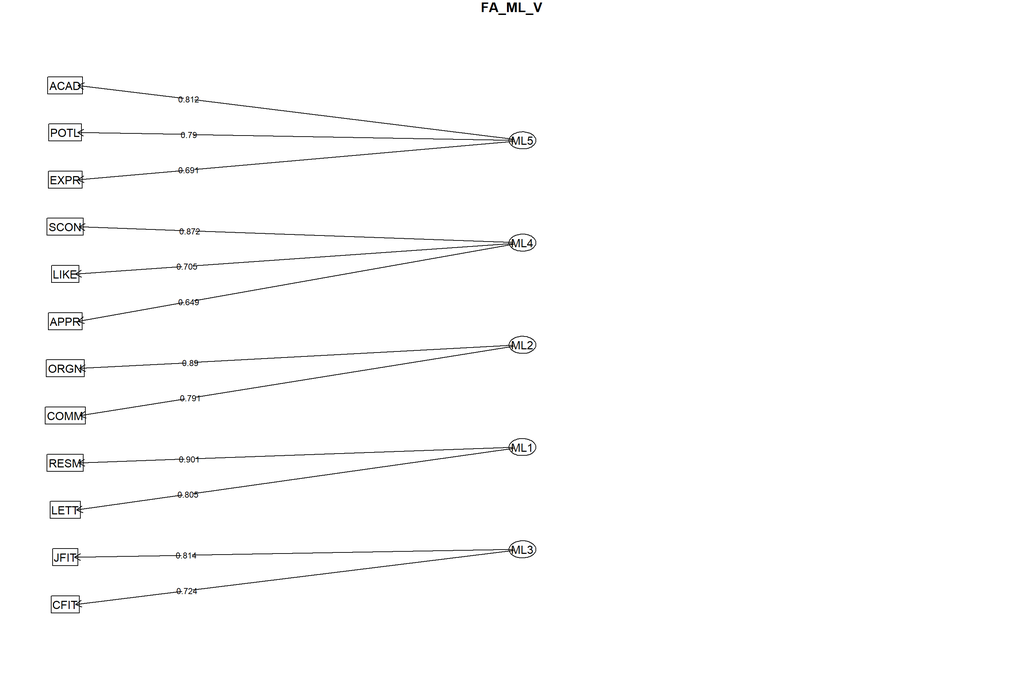

```r
##################################
# Graph the factor loading matrices
##################################
fa.diagram(FA_ML_V_5F,
           sort=TRUE,
           cut=0,
           digits=3,
           main="FA_ML_V",
           cex=0.75)
```

```r
##################################
# computing the internal consistency
# measure of reliability using the
# Cronbach's alpha coefficient
# for each factor
##################################
alpha(DPA.Descriptors.Numeric[,c("ACAD","POTL","EXPR")])
```

```
##
## Reliability analysis
## Call: alpha(x = DPA.Descriptors.Numeric[, c("ACAD", "POTL", "EXPR")])
##
##   raw_alpha std.alpha G6(smc) average_r S/N   ase mean  sd median_r
##       0.89      0.89    0.85      0.72 7.8 0.028  7.3 1.2      0.7
##
##     95% confidence boundaries
##          lower alpha upper
## Feldt     0.82  0.89  0.93
## Duhachek  0.83  0.89  0.94
##
##  Reliability if an item is dropped:
##      raw_alpha std.alpha G6(smc) average_r S/N alpha se var.r med.r
## ACAD      0.83      0.83    0.70      0.70 4.7    0.049    NA  0.70
## POTL      0.80      0.80    0.67      0.67 4.0    0.056    NA  0.67
## EXPR      0.88      0.89    0.80      0.80 7.8    0.032    NA  0.80
##
##  Item statistics
##       n raw.r std.r r.cor r.drop mean  sd
## ACAD 50  0.91  0.91  0.85   0.79  7.4 1.3
## POTL 50  0.92  0.92  0.88   0.82  7.3 1.4
## EXPR 50  0.88  0.88  0.76   0.72  7.3 1.4
##
## Non missing response frequency for each item
##         4    5    6    7    8    9   10 miss
## ACAD 0.02 0.02 0.22 0.28 0.24 0.18 0.04    0
## POTL 0.04 0.06 0.18 0.22 0.30 0.18 0.02    0
## EXPR 0.00 0.10 0.20 0.24 0.24 0.18 0.04    0
```

```r
alpha(DPA.Descriptors.Numeric[,c("SCON","LIKE","APPR")])
```

```
##
## Reliability analysis
## Call: alpha(x = DPA.Descriptors.Numeric[, c("SCON", "LIKE", "APPR")])
##
##   raw_alpha std.alpha G6(smc) average_r S/N   ase mean   sd median_r
##       0.87      0.87    0.83       0.7 6.9 0.031  7.4 0.99      0.7
##
##     95% confidence boundaries
##          lower alpha upper
## Feldt     0.80  0.87  0.92
## Duhachek  0.81  0.87  0.93
##
##  Reliability if an item is dropped:
##      raw_alpha std.alpha G6(smc) average_r S/N alpha se var.r med.r
## SCON      0.78      0.78    0.64      0.64 3.5    0.062    NA  0.64
## LIKE      0.82      0.82    0.70      0.70 4.6    0.051    NA  0.70
## APPR      0.86      0.86    0.75      0.75 6.1    0.040    NA  0.75
##
##  Item statistics
##       n raw.r std.r r.cor r.drop mean  sd
## SCON 50  0.92  0.91  0.86   0.80  7.3 1.2
## LIKE 50  0.90  0.89  0.82   0.76  7.4 1.1
## APPR 50  0.86  0.87  0.76   0.71  7.4 1.0
##
## Non missing response frequency for each item
##         4    5    6    7    8    9   10 miss
## SCON 0.00 0.08 0.14 0.32 0.28 0.18 0.00    0
## LIKE 0.02 0.04 0.12 0.32 0.36 0.14 0.00    0
## APPR 0.00 0.02 0.16 0.32 0.38 0.10 0.02    0
```

```r
alpha(DPA.Descriptors.Numeric[,c("ORGN","COMM")])
```

```
##
## Reliability analysis
## Call: alpha(x = DPA.Descriptors.Numeric[, c("ORGN", "COMM")])
##
##   raw_alpha std.alpha G6(smc) average_r S/N   ase mean  sd median_r
##       0.92      0.93    0.86      0.86  12 0.021  6.9 1.5     0.86
##
##     95% confidence boundaries
##          lower alpha upper
## Feldt     0.87  0.92  0.96
## Duhachek  0.88  0.92  0.97
##
##  Reliability if an item is dropped:
##      raw_alpha std.alpha G6(smc) average_r S/N alpha se var.r med.r
## ORGN      0.92      0.86    0.74      0.86 6.2       NA     0  0.86
## COMM      0.80      0.86    0.74      0.86 6.2       NA     0  0.86
##
##  Item statistics
##       n raw.r std.r r.cor r.drop mean  sd
## ORGN 50  0.97  0.96   0.9   0.86  6.9 1.6
## COMM 50  0.96  0.96   0.9   0.86  6.9 1.5
##
## Non missing response frequency for each item
##         3    4    5   6    7    8    9   10 miss
## ORGN 0.02 0.04 0.20 0.1 0.24 0.24 0.16 0.00    0
## COMM 0.04 0.04 0.06 0.2 0.30 0.28 0.06 0.02    0
```

```r
alpha(DPA.Descriptors.Numeric[,c("RESM","LETT")])
```

```
##
## Reliability analysis
## Call: alpha(x = DPA.Descriptors.Numeric[, c("RESM", "LETT")])
##
##   raw_alpha std.alpha G6(smc) average_r S/N   ase mean  sd median_r
##       0.91      0.91    0.84      0.84  10 0.025  7.2 1.6     0.84
##
##     95% confidence boundaries
##          lower alpha upper
## Feldt     0.84  0.91  0.95
## Duhachek  0.86  0.91  0.96
##
##  Reliability if an item is dropped:
##      raw_alpha std.alpha G6(smc) average_r S/N alpha se var.r med.r
## RESM      0.84      0.84     0.7      0.84 5.1       NA     0  0.84
## LETT      0.83      0.84     0.7      0.84 5.1       NA     0  0.84
##
##  Item statistics
##       n raw.r std.r r.cor r.drop mean  sd
## RESM 50  0.96  0.96  0.88   0.84  7.2 1.7
## LETT 50  0.96  0.96  0.88   0.84  7.2 1.7
##
## Non missing response frequency for each item
##         4    5    6    7    8    9   10 miss
## RESM 0.08 0.06 0.22 0.18 0.16 0.24 0.06    0
## LETT 0.06 0.12 0.14 0.22 0.24 0.12 0.10    0
```

```r
alpha(DPA.Descriptors.Numeric[,c("JFIT","CFIT")])
```

```
##
## Reliability analysis
## Call: alpha(x = DPA.Descriptors.Numeric[, c("JFIT", "CFIT")])
##
##   raw_alpha std.alpha G6(smc) average_r S/N   ase mean  sd median_r
##       0.94      0.94    0.88      0.88  15 0.018    7 1.6     0.88
##
##     95% confidence boundaries
##          lower alpha upper
## Feldt     0.89  0.94  0.96
## Duhachek  0.90  0.94  0.97
##
##  Reliability if an item is dropped:
##      raw_alpha std.alpha G6(smc) average_r S/N alpha se var.r med.r
## JFIT      0.87      0.88    0.78      0.88 7.5       NA     0  0.88
## CFIT      0.90      0.88    0.78      0.88 7.5       NA     0  0.88
##
##  Item statistics
##       n raw.r std.r r.cor r.drop mean  sd
## JFIT 50  0.97  0.97  0.91   0.88  7.0 1.6
## CFIT 50  0.97  0.97  0.91   0.88  6.9 1.6
##
## Non missing response frequency for each item
##         3    4    5    6    7    8    9   10 miss
## JFIT 0.06 0.00 0.06 0.22 0.26 0.24 0.12 0.04    0
## CFIT 0.02 0.06 0.16 0.12 0.22 0.30 0.08 0.04    0
```

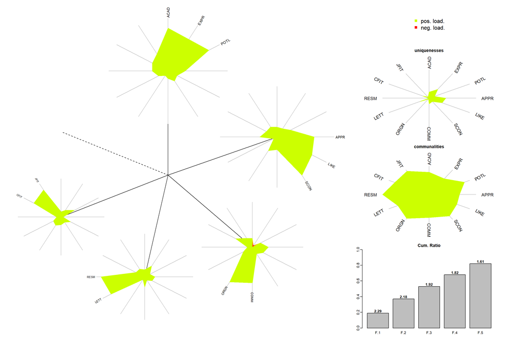

```r
##################################
# Formulating the dandelion plot to
# visualize both factor variances and loadings
# from the factor loading matrices
##################################
FA_ML_V_5F_FactorLoading <- factload(DPA.Descriptors.Numeric,
                                  cormeth = "pearson",
                                  method = "mle",
                                  nfac = 5,
                                  rotation = "varimax")

DandelionPlotPalette <- rev(rainbow(100, start = 0, end = 0.2))

dandelion(FA_ML_V_5F_FactorLoading,
          bound=0,
          mcex=c(1,1.2),
          palet=DandelionPlotPalette)
```

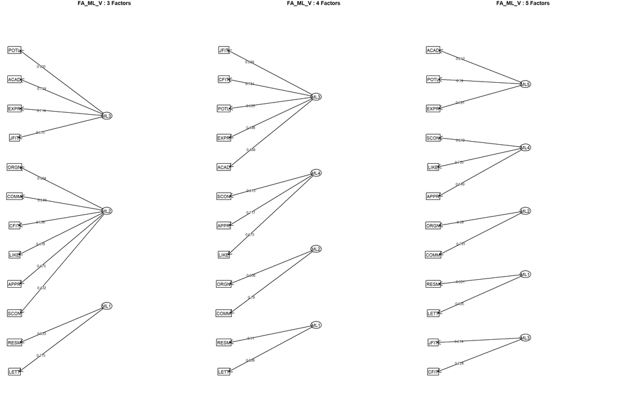

```r
par(mfrow=c(1,3))
fa.diagram(FA_ML_V_3F,
           sort=TRUE,
           cut=0,
           digits=3,
           main="FA_ML_V : 3 Factors",
           cex=0.75)
fa.diagram(FA_ML_V_4F,
           sort=TRUE,
           cut=0,
           digits=3,
           main="FA_ML_V : 4 Factors",
           cex=0.75)
fa.diagram(FA_ML_V_5F,
           sort=TRUE,
           cut=0,
           digits=3,
           main="FA_ML_V : 5 Factors",
           cex=0.75)
```

### 1.6.4 Maximum Likelihood Factor Extraction and Promax Rotation (FA_ML_P)

**Code Chunk | Output**

```r
##################################
# Conducting exploratory factor analysis
# using Maximum Likelihood extraction
# and Promax rotation
# with 3 factors
##################################
(FA_ML_P_3F <- fa(DPA.Descriptors.Numeric,
              nfactors = 3,
              fm="ml",
              rotate = "promax",
              residuals=TRUE,
              SMC=TRUE,
              n.obs=nrow(DPA.Descriptors.Numeric)))
```

```
## Factor Analysis using method =  ml
## Call: fa(r = DPA.Descriptors.Numeric, nfactors = 3, n.obs = nrow(DPA.Descriptors.Numeric),
##     rotate = "promax", residuals = TRUE, SMC = TRUE, fm = "ml")
## Standardized loadings (pattern matrix) based upon correlation matrix
##        ML3   ML2   ML1   h2    u2 com
## ACAD  0.88 -0.04 -0.05 0.67 0.326 1.0
## APPR  0.19  0.40  0.19 0.46 0.543 1.9
## COMM -0.20  0.99  0.05 0.80 0.203 1.1
## CFIT  0.44  0.47 -0.05 0.62 0.377 2.0
## EXPR  0.85 -0.32  0.17 0.61 0.385 1.4
## JFIT  0.60  0.28 -0.04 0.62 0.379 1.4
## LETT -0.08  0.04  0.87 0.71 0.289 1.0
## LIKE  0.19  0.41  0.15 0.44 0.563 1.7
## ORGN -0.20  1.18 -0.18 0.96 0.043 1.1
## POTL  1.08 -0.02 -0.18 0.92 0.079 1.1
## RESM -0.02 -0.10  1.06 1.00 0.005 1.0
## SCON  0.28  0.35  0.09 0.40 0.597 2.1
##
##                        ML3  ML2  ML1
## SS loadings           3.27 3.05 1.89
## Proportion Var        0.27 0.25 0.16
## Cumulative Var        0.27 0.53 0.68
## Proportion Explained  0.40 0.37 0.23
## Cumulative Proportion 0.40 0.77 1.00
##
##  With factor correlations of
##      ML3  ML2  ML1
## ML3 1.00 0.67 0.64
## ML2 0.67 1.00 0.58
## ML1 0.64 0.58 1.00
##
## Mean item complexity =  1.4
## Test of the hypothesis that 3 factors are sufficient.
##
## The degrees of freedom for the null model are  66  and the objective function was  10.7 with Chi Square of  472.51
## The degrees of freedom for the model are 33  and the objective function was  2.22
##
## The root mean square of the residuals (RMSR) is  0.08
## The df corrected root mean square of the residuals is  0.11
##
## The harmonic number of observations is  50 with the empirical chi square  41.84  with prob <  0.14
## The total number of observations was  50  with Likelihood Chi Square =  93.49  with prob <  1.1e-07
##
## Tucker Lewis Index of factoring reliability =  0.686
## RMSEA index =  0.19  and the 90 % confidence intervals are  0.148 0.24
## BIC =  -35.6
## Fit based upon off diagonal values = 0.98
## Measures of factor score adequacy
##                                                    ML3  ML2  ML1
## Correlation of (regression) scores with factors   0.98 0.99 1.00
## Multiple R square of scores with factors          0.96 0.97 1.00
## Minimum correlation of possible factor scores     0.91 0.95 0.99
```

```r
(FA_ML_P_3F_Summary <- FA_ML_P_3F %>%
  model_parameters(sort = TRUE, threshold = "max"))
```

```
## # Rotated loadings from Factor Analysis (promax-rotation)
##
## Variable | ML3  | ML2  | ML1  | Complexity | Uniqueness
## -------------------------------------------------------
## POTL     | 1.08 |      |      |    1.06    |    0.08
## ACAD     | 0.88 |      |      |    1.01    |    0.33
## EXPR     | 0.85 |      |      |    1.36    |    0.39
## JFIT     | 0.60 |      |      |    1.44    |    0.38
## ORGN     |      | 1.18 |      |    1.10    |    0.04
## COMM     |      | 0.99 |      |    1.09    |    0.20
## CFIT     |      | 0.47 |      |    2.02    |    0.38
## LIKE     |      | 0.41 |      |    1.70    |    0.56
## APPR     |      | 0.40 |      |    1.90    |    0.54
## SCON     |      | 0.35 |      |    2.08    |    0.60
## RESM     |      |      | 1.06 |    1.02    |  4.98e-03
## LETT     |      |      | 0.87 |    1.02    |    0.29
##
## The 3 latent factors (promax rotation) accounted for 68.42% of the total variance of the original data (ML3 = 27.29%, ML2 = 25.39%, ML1 = 15.75%).
```

```r
summary(FA_ML_P_3F_Summary)
```

```
## # (Explained) Variance of Components
##
## Parameter                       |   ML3 |   ML2 |   ML1
## -------------------------------------------------------
## Eigenvalues                     | 6.079 | 1.261 | 0.922
## Variance Explained              | 0.273 | 0.254 | 0.157
## Variance Explained (Cumulative) | 0.273 | 0.527 | 0.684
## Variance Explained (Proportion) | 0.399 | 0.371 | 0.230
```

```r
##################################
# Extracting the residuals
# from the Exploratory Factor Analysis
##################################
(FA_ML_P_3F_Residual <- residuals(FA_ML_P_3F,
                              diag=FALSE,
                              na.rm=TRUE))
```

```
##      ACAD  APPR  COMM  CFIT  EXPR  JFIT  LETT  LIKE  ORGN  POTL  RESM
## ACAD    NA
## APPR  0.02    NA
## COMM  0.04 -0.04    NA
## CFIT -0.07 -0.10 -0.01    NA
## EXPR  0.05 -0.07 -0.02 -0.06    NA
## JFIT -0.08 -0.09 -0.02  0.27  0.00    NA
## LETT -0.06 -0.14 -0.02  0.05  0.06  0.06    NA
## LIKE -0.04  0.19 -0.04 -0.02 -0.06  0.04 -0.06    NA
## ORGN  0.00  0.00  0.00 -0.01  0.01 -0.01  0.01 -0.01    NA
## POTL  0.01  0.01  0.00  0.00  0.00 -0.01  0.00 -0.01  0.00    NA
## RESM  0.00  0.00  0.00  0.00  0.00  0.00  0.00  0.00  0.00  0.00    NA
## SCON -0.04  0.27 -0.05 -0.03  0.03 -0.02 -0.15  0.34  0.00 -0.01  0.00
## [1]    NA
```

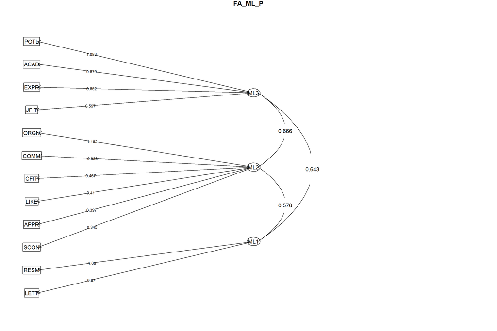

```r
##################################
# Graph the factor loading matrices
##################################
fa.diagram(FA_ML_P_3F,
           sort=TRUE,
           cut=0,
           digits=3,
           main="FA_ML_P",
           cex=0.75)
```

```r
##################################
# computing the internal consistency
# measure of reliability using the
# Cronbach's alpha coefficient
# for each factor
##################################
alpha(DPA.Descriptors.Numeric[,c("POTL","ACAD","EXPR","JFIT")])
```

```
##
## Reliability analysis
## Call: alpha(x = DPA.Descriptors.Numeric[, c("POTL", "ACAD", "EXPR",
##     "JFIT")])
##
##   raw_alpha std.alpha G6(smc) average_r S/N   ase mean  sd median_r
##       0.88      0.88    0.87      0.66 7.6 0.028  7.3 1.2     0.69
##
##     95% confidence boundaries
##          lower alpha upper
## Feldt     0.81  0.88  0.93
## Duhachek  0.82  0.88  0.93
##
##  Reliability if an item is dropped:
##      raw_alpha std.alpha G6(smc) average_r S/N alpha se  var.r med.r
## POTL      0.79      0.80    0.74      0.58 4.1    0.051 0.0063  0.54
## ACAD      0.84      0.84    0.80      0.64 5.4    0.040 0.0111  0.70
## EXPR      0.86      0.86    0.84      0.68 6.4    0.036 0.0169  0.71
## JFIT      0.89      0.89    0.85      0.72 7.8    0.028 0.0043  0.70
##
##  Item statistics
##       n raw.r std.r r.cor r.drop mean  sd
## POTL 50  0.93  0.93  0.92   0.87  7.3 1.4
## ACAD 50  0.86  0.87  0.83   0.76  7.4 1.3
## EXPR 50  0.83  0.84  0.75   0.71  7.3 1.4
## JFIT 50  0.82  0.80  0.71   0.65  7.0 1.6
##
## Non missing response frequency for each item
##         3    4    5    6    7    8    9   10 miss
## POTL 0.00 0.04 0.06 0.18 0.22 0.30 0.18 0.02    0
## ACAD 0.00 0.02 0.02 0.22 0.28 0.24 0.18 0.04    0
## EXPR 0.00 0.00 0.10 0.20 0.24 0.24 0.18 0.04    0
## JFIT 0.06 0.00 0.06 0.22 0.26 0.24 0.12 0.04    0
```

```r
alpha(DPA.Descriptors.Numeric[,c("ORGN","COMM","LIKE","APPR","SCON","CFIT")])
```

```
##
## Reliability analysis
## Call: alpha(x = DPA.Descriptors.Numeric[, c("ORGN", "COMM", "LIKE",
##     "APPR", "SCON", "CFIT")])
##
##   raw_alpha std.alpha G6(smc) average_r S/N   ase mean  sd median_r
##       0.88      0.89     0.9      0.57 7.8 0.026  7.1 1.1     0.53
##
##     95% confidence boundaries
##          lower alpha upper
## Feldt     0.82  0.88  0.92
## Duhachek  0.83  0.88  0.93
##
##  Reliability if an item is dropped:
##      raw_alpha std.alpha G6(smc) average_r S/N alpha se var.r med.r
## ORGN      0.84      0.86    0.85      0.55 6.0    0.036 0.014  0.49
## COMM      0.85      0.87    0.86      0.56 6.4    0.034 0.012  0.53
## LIKE      0.86      0.86    0.88      0.56 6.4    0.030 0.019  0.52
## APPR      0.86      0.87    0.89      0.57 6.7    0.030 0.019  0.51
## SCON      0.86      0.87    0.87      0.57 6.5    0.029 0.015  0.53
## CFIT      0.87      0.88    0.90      0.59 7.3    0.029 0.020  0.53
##
##  Item statistics
##       n raw.r std.r r.cor r.drop mean  sd
## ORGN 50  0.87  0.84  0.84   0.78  6.9 1.6
## COMM 50  0.84  0.81  0.79   0.74  6.9 1.5
## LIKE 50  0.78  0.81  0.77   0.69  7.4 1.1
## APPR 50  0.75  0.79  0.73   0.67  7.4 1.0
## SCON 50  0.76  0.80  0.76   0.67  7.3 1.2
## CFIT 50  0.78  0.75  0.66   0.64  6.9 1.6
##
## Non missing response frequency for each item
##         3    4    5    6    7    8    9   10 miss
## ORGN 0.02 0.04 0.20 0.10 0.24 0.24 0.16 0.00    0
## COMM 0.04 0.04 0.06 0.20 0.30 0.28 0.06 0.02    0
## LIKE 0.00 0.02 0.04 0.12 0.32 0.36 0.14 0.00    0
## APPR 0.00 0.00 0.02 0.16 0.32 0.38 0.10 0.02    0
## SCON 0.00 0.00 0.08 0.14 0.32 0.28 0.18 0.00    0
## CFIT 0.02 0.06 0.16 0.12 0.22 0.30 0.08 0.04    0
```

```r
alpha(DPA.Descriptors.Numeric[,c("RESM","LETT")])
```

```
##
## Reliability analysis
## Call: alpha(x = DPA.Descriptors.Numeric[, c("RESM", "LETT")])
##
##   raw_alpha std.alpha G6(smc) average_r S/N   ase mean  sd median_r
##       0.91      0.91    0.84      0.84  10 0.025  7.2 1.6     0.84
##
##     95% confidence boundaries
##          lower alpha upper
## Feldt     0.84  0.91  0.95
## Duhachek  0.86  0.91  0.96
##
##  Reliability if an item is dropped:
##      raw_alpha std.alpha G6(smc) average_r S/N alpha se var.r med.r
## RESM      0.84      0.84     0.7      0.84 5.1       NA     0  0.84
## LETT      0.83      0.84     0.7      0.84 5.1       NA     0  0.84
##
##  Item statistics
##       n raw.r std.r r.cor r.drop mean  sd
## RESM 50  0.96  0.96  0.88   0.84  7.2 1.7
## LETT 50  0.96  0.96  0.88   0.84  7.2 1.7
##
## Non missing response frequency for each item
##         4    5    6    7    8    9   10 miss
## RESM 0.08 0.06 0.22 0.18 0.16 0.24 0.06    0
## LETT 0.06 0.12 0.14 0.22 0.24 0.12 0.10    0
```

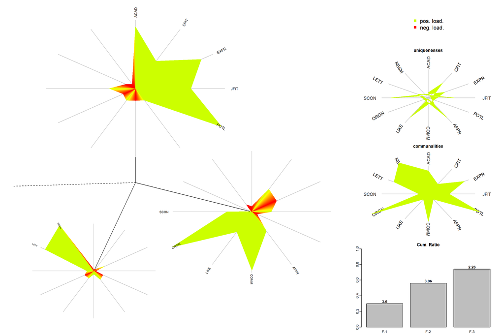

```r
##################################
# Formulating the dandelion plot to
# visualize both factor variances and loadings
# from the factor loading matrices
##################################
FA_ML_P_3F_FactorLoading <- factload(DPA.Descriptors.Numeric,
                                  cormeth = "pearson",
                                  method = "mle",
                                  nfac = 3,
                                  rotation = "promax")

DandelionPlotPalette <- rev(rainbow(100, start = 0, end = 0.2))

dandelion(FA_ML_P_3F_FactorLoading,
          bound=0,
          mcex=c(1,1.2),
          palet=DandelionPlotPalette)
```

```r
##################################
# Conducting exploratory factor analysis
# using Maximum Likelihood extraction
# and Promax rotation
# with 4 factors
##################################
(FA_ML_P_4F <- fa(DPA.Descriptors.Numeric,
              nfactors = 4,
              fm="ml",
              rotate = "promax",
              residuals=TRUE,
              SMC=TRUE,
              n.obs=nrow(DPA.Descriptors.Numeric)))
```

```
## Factor Analysis using method =  ml
## Call: fa(r = DPA.Descriptors.Numeric, nfactors = 4, n.obs = nrow(DPA.Descriptors.Numeric),
##     rotate = "promax", residuals = TRUE, SMC = TRUE, fm = "ml")
## Standardized loadings (pattern matrix) based upon correlation matrix
##        ML3   ML4   ML1   ML2   h2    u2 com
## ACAD  0.44  0.26  0.07 -0.03 0.45 0.546 1.7
## APPR -0.13  0.80  0.07  0.15 0.68 0.325 1.1
## COMM  0.03  0.10  0.16  0.76 0.79 0.206 1.1
## CFIT  0.91 -0.18 -0.04  0.28 0.85 0.148 1.3
## EXPR  0.47  0.16  0.22 -0.24 0.46 0.535 2.2
## JFIT  1.04 -0.16 -0.07  0.11 0.91 0.089 1.1
## LETT  0.06 -0.21  0.90  0.14 0.78 0.224 1.2
## LIKE  0.09  0.70 -0.02  0.11 0.65 0.350 1.1
## ORGN  0.08  0.16 -0.06  0.89 0.97 0.027 1.1
## POTL  0.70  0.22 -0.06 -0.04 0.65 0.347 1.2
## RESM -0.12  0.15  0.99 -0.03 1.00 0.005 1.1
## SCON  0.01  0.93 -0.12  0.01 0.78 0.220 1.0
##
##                        ML3  ML4  ML1  ML2
## SS loadings           2.93 2.36 1.85 1.84
## Proportion Var        0.24 0.20 0.15 0.15
## Cumulative Var        0.24 0.44 0.60 0.75
## Proportion Explained  0.33 0.26 0.21 0.20
## Cumulative Proportion 0.33 0.59 0.80 1.00
##
##  With factor correlations of
##      ML3  ML4  ML1  ML2
## ML3 1.00 0.66 0.60 0.40
## ML4 0.66 1.00 0.53 0.41
## ML1 0.60 0.53 1.00 0.27
## ML2 0.40 0.41 0.27 1.00
##
## Mean item complexity =  1.3
## Test of the hypothesis that 4 factors are sufficient.
##
## The degrees of freedom for the null model are  66  and the objective function was  10.7 with Chi Square of  472.51
## The degrees of freedom for the model are 24  and the objective function was  1.36
##
## The root mean square of the residuals (RMSR) is  0.06
## The df corrected root mean square of the residuals is  0.1
##
## The harmonic number of observations is  50 with the empirical chi square  22.17  with prob <  0.57
## The total number of observations was  50  with Likelihood Chi Square =  56.38  with prob <  2e-04
##
## Tucker Lewis Index of factoring reliability =  0.764
## RMSEA index =  0.163  and the 90 % confidence intervals are  0.11 0.223
## BIC =  -37.51
## Fit based upon off diagonal values = 0.99
## Measures of factor score adequacy
##                                                    ML3  ML4  ML1  ML2
## Correlation of (regression) scores with factors   0.98 0.95 1.00 0.98
## Multiple R square of scores with factors          0.95 0.90 0.99 0.97
## Minimum correlation of possible factor scores     0.90 0.81 0.99 0.93
```

```r
(FA_ML_P_4F_Summary <- FA_ML_P_4F %>%
  model_parameters(sort = TRUE, threshold = "max"))
```

```
## # Rotated loadings from Factor Analysis (promax-rotation)
##
## Variable | ML3  | ML4  | ML1  | ML2  | Complexity | Uniqueness
## --------------------------------------------------------------
## JFIT     | 1.04 |      |      |      |    1.08    |    0.09
## CFIT     | 0.91 |      |      |      |    1.27    |    0.15
## POTL     | 0.70 |      |      |      |    1.22    |    0.35
## EXPR     | 0.47 |      |      |      |    2.21    |    0.54
## ACAD     | 0.44 |      |      |      |    1.67    |    0.55
## SCON     |      | 0.93 |      |      |    1.04    |    0.22
## APPR     |      | 0.80 |      |      |    1.14    |    0.32
## LIKE     |      | 0.70 |      |      |    1.08    |    0.35
## RESM     |      |      | 0.99 |      |    1.08    |  5.00e-03
## LETT     |      |      | 0.90 |      |    1.18    |    0.22
## ORGN     |      |      |      | 0.89 |    1.09    |    0.03
## COMM     |      |      |      | 0.76 |    1.13    |    0.21
##
## The 4 latent factors (promax rotation) accounted for 74.82% of the total variance of the original data (ML3 = 24.45%, ML4 = 19.64%, ML1 = 15.41%, ML2 = 15.32%).
```

```r
summary(FA_ML_P_4F_Summary)
```

```
## # (Explained) Variance of Components
##
## Parameter                       |   ML3 |   ML4 |   ML1 |   ML2
## ---------------------------------------------------------------
## Eigenvalues                     | 6.146 | 1.248 | 0.890 | 0.846
## Variance Explained              | 0.245 | 0.196 | 0.154 | 0.153
## Variance Explained (Cumulative) | 0.245 | 0.441 | 0.595 | 0.748
## Variance Explained (Proportion) | 0.327 | 0.263 | 0.206 | 0.205
```

```r
##################################
# Extracting the residuals
# from the Exploratory Factor Analysis
##################################
(FA_ML_P_4F_Residual <- residuals(FA_ML_P_4F,
                              diag=FALSE,
                              na.rm=TRUE))
```

```
##      ACAD  APPR  COMM  CFIT  EXPR  JFIT  LETT  LIKE  ORGN  POTL  RESM
## ACAD    NA
## APPR  0.03    NA
## COMM  0.05 -0.01    NA
## CFIT -0.04  0.00  0.00    NA
## EXPR  0.24 -0.05 -0.02 -0.08    NA
## JFIT -0.04  0.00  0.00  0.01 -0.01    NA
## LETT -0.04 -0.03 -0.03 -0.01  0.06  0.00    NA
## LIKE -0.08 -0.01  0.00 -0.01 -0.09  0.03  0.04    NA
## ORGN  0.00  0.00  0.00  0.00  0.01  0.00  0.01  0.00    NA
## POTL  0.26  0.03  0.02 -0.02  0.20 -0.02  0.00 -0.05  0.00    NA
## RESM  0.00  0.00  0.00  0.00  0.00  0.00  0.00  0.00  0.00  0.00    NA
## SCON -0.08 -0.01 -0.01  0.02  0.00  0.00 -0.01  0.05  0.00 -0.05  0.00
## [1]    NA
```

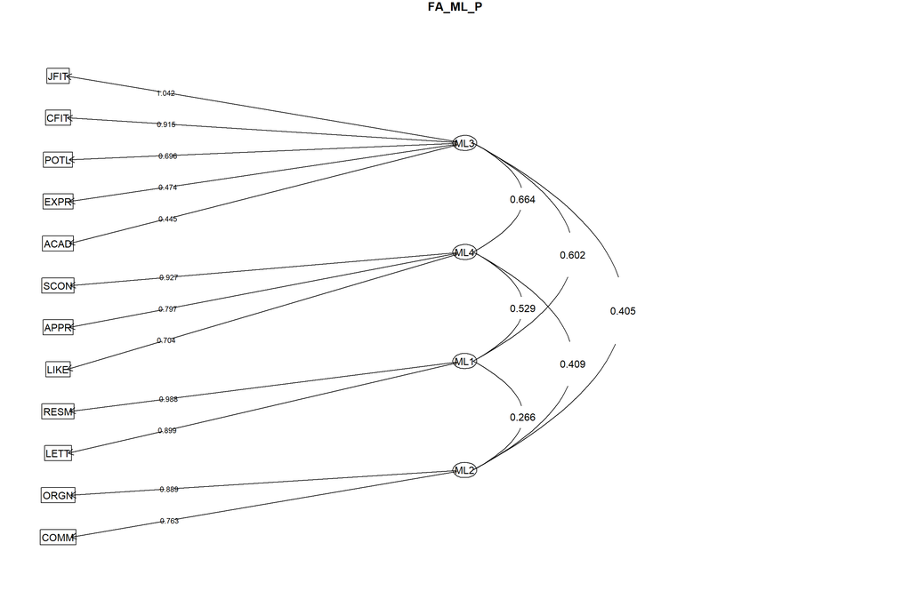

```r
##################################
# Graph the factor loading matrices
##################################
fa.diagram(FA_ML_P_4F,
           sort=TRUE,
           cut=0,
           digits=3,
           main="FA_ML_P",
           cex=0.75)
```

```r
##################################
# computing the internal consistency
# measure of reliability using the
# Cronbach's alpha coefficient
# for each factor
##################################
alpha(DPA.Descriptors.Numeric[,c("JFIT","CFIT","POTL","EXPR","ACAD")])
```

```
##
## Reliability analysis
## Call: alpha(x = DPA.Descriptors.Numeric[, c("JFIT", "CFIT", "POTL",
##     "EXPR", "ACAD")])
##
##   raw_alpha std.alpha G6(smc) average_r S/N   ase mean  sd median_r
##        0.9       0.9    0.92      0.64 8.8 0.024  7.2 1.2     0.66
##
##     95% confidence boundaries
##          lower alpha upper
## Feldt     0.84   0.9  0.94
## Duhachek  0.85   0.9  0.94
##
##  Reliability if an item is dropped:
##      raw_alpha std.alpha G6(smc) average_r S/N alpha se var.r med.r
## JFIT      0.86      0.87    0.86      0.62 6.5    0.034 0.021  0.66
## CFIT      0.88      0.88    0.87      0.66 7.6    0.028 0.011  0.69
## POTL      0.85      0.85    0.88      0.58 5.6    0.036 0.029  0.53
## EXPR      0.89      0.89    0.91      0.68 8.5    0.025 0.022  0.68
## ACAD      0.88      0.88    0.90      0.64 7.3    0.029 0.028  0.68
##
##  Item statistics
##       n raw.r std.r r.cor r.drop mean  sd
## JFIT 50  0.88  0.87  0.86   0.80  7.0 1.6
## CFIT 50  0.84  0.82  0.80   0.72  6.9 1.6
## POTL 50  0.91  0.92  0.90   0.85  7.3 1.4
## EXPR 50  0.76  0.78  0.71   0.64  7.3 1.4
## ACAD 50  0.81  0.83  0.78   0.72  7.4 1.3
##
## Non missing response frequency for each item
##         3    4    5    6    7    8    9   10 miss
## JFIT 0.06 0.00 0.06 0.22 0.26 0.24 0.12 0.04    0
## CFIT 0.02 0.06 0.16 0.12 0.22 0.30 0.08 0.04    0
## POTL 0.00 0.04 0.06 0.18 0.22 0.30 0.18 0.02    0
## EXPR 0.00 0.00 0.10 0.20 0.24 0.24 0.18 0.04    0
## ACAD 0.00 0.02 0.02 0.22 0.28 0.24 0.18 0.04    0
```

```r
alpha(DPA.Descriptors.Numeric[,c("SCON","APPR","LIKE")])
```

```
##
## Reliability analysis
## Call: alpha(x = DPA.Descriptors.Numeric[, c("SCON", "APPR", "LIKE")])
##
##   raw_alpha std.alpha G6(smc) average_r S/N   ase mean   sd median_r
##       0.87      0.87    0.83       0.7 6.9 0.031  7.4 0.99      0.7
##
##     95% confidence boundaries
##          lower alpha upper
## Feldt     0.80  0.87  0.92
## Duhachek  0.81  0.87  0.93
##
##  Reliability if an item is dropped:
##      raw_alpha std.alpha G6(smc) average_r S/N alpha se var.r med.r
## SCON      0.78      0.78    0.64      0.64 3.5    0.062    NA  0.64
## APPR      0.86      0.86    0.75      0.75 6.1    0.040    NA  0.75
## LIKE      0.82      0.82    0.70      0.70 4.6    0.051    NA  0.70
##
##  Item statistics
##       n raw.r std.r r.cor r.drop mean  sd
## SCON 50  0.92  0.91  0.86   0.80  7.3 1.2
## APPR 50  0.86  0.87  0.76   0.71  7.4 1.0
## LIKE 50  0.90  0.89  0.82   0.76  7.4 1.1
##
## Non missing response frequency for each item
##         4    5    6    7    8    9   10 miss
## SCON 0.00 0.08 0.14 0.32 0.28 0.18 0.00    0
## APPR 0.00 0.02 0.16 0.32 0.38 0.10 0.02    0
## LIKE 0.02 0.04 0.12 0.32 0.36 0.14 0.00    0
```

```r
alpha(DPA.Descriptors.Numeric[,c("ORGN","COMM")])
```

```
##
## Reliability analysis
## Call: alpha(x = DPA.Descriptors.Numeric[, c("ORGN", "COMM")])
##
##   raw_alpha std.alpha G6(smc) average_r S/N   ase mean  sd median_r
##       0.92      0.93    0.86      0.86  12 0.021  6.9 1.5     0.86
##
##     95% confidence boundaries
##          lower alpha upper
## Feldt     0.87  0.92  0.96
## Duhachek  0.88  0.92  0.97
##
##  Reliability if an item is dropped:
##      raw_alpha std.alpha G6(smc) average_r S/N alpha se var.r med.r
## ORGN      0.92      0.86    0.74      0.86 6.2       NA     0  0.86
## COMM      0.80      0.86    0.74      0.86 6.2       NA     0  0.86
##
##  Item statistics
##       n raw.r std.r r.cor r.drop mean  sd
## ORGN 50  0.97  0.96   0.9   0.86  6.9 1.6
## COMM 50  0.96  0.96   0.9   0.86  6.9 1.5
##
## Non missing response frequency for each item
##         3    4    5   6    7    8    9   10 miss
## ORGN 0.02 0.04 0.20 0.1 0.24 0.24 0.16 0.00    0
## COMM 0.04 0.04 0.06 0.2 0.30 0.28 0.06 0.02    0
```

```r
alpha(DPA.Descriptors.Numeric[,c("RESM","LETT")])
```

```
##
## Reliability analysis
## Call: alpha(x = DPA.Descriptors.Numeric[, c("RESM", "LETT")])
##
##   raw_alpha std.alpha G6(smc) average_r S/N   ase mean  sd median_r
##       0.91      0.91    0.84      0.84  10 0.025  7.2 1.6     0.84
##
##     95% confidence boundaries
##          lower alpha upper
## Feldt     0.84  0.91  0.95
## Duhachek  0.86  0.91  0.96
##
##  Reliability if an item is dropped:
##      raw_alpha std.alpha G6(smc) average_r S/N alpha se var.r med.r
## RESM      0.84      0.84     0.7      0.84 5.1       NA     0  0.84
## LETT      0.83      0.84     0.7      0.84 5.1       NA     0  0.84
##
##  Item statistics
##       n raw.r std.r r.cor r.drop mean  sd
## RESM 50  0.96  0.96  0.88   0.84  7.2 1.7
## LETT 50  0.96  0.96  0.88   0.84  7.2 1.7
##
## Non missing response frequency for each item
##         4    5    6    7    8    9   10 miss
## RESM 0.08 0.06 0.22 0.18 0.16 0.24 0.06    0
## LETT 0.06 0.12 0.14 0.22 0.24 0.12 0.10    0
```

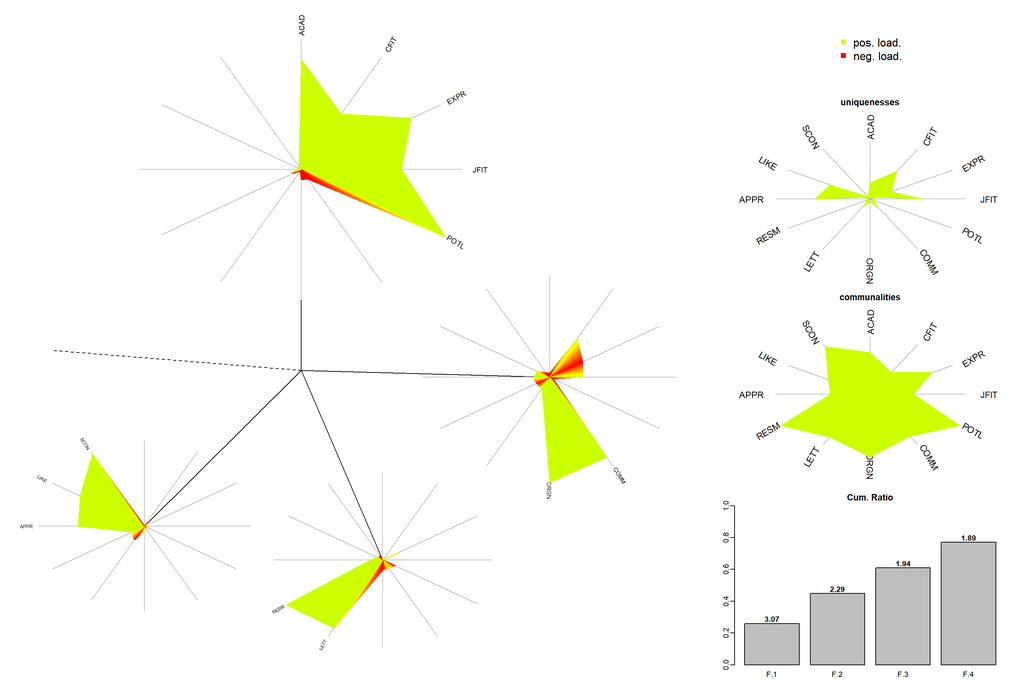

```r
##################################
# Formulating the dandelion plot to
# visualize both factor variances and loadings
# from the factor loading matrices
##################################
FA_ML_P_4F_FactorLoading <- factload(DPA.Descriptors.Numeric,
                                  cormeth = "pearson",
                                  method = "mle",
                                  nfac = 4,
                                  rotation = "promax")

DandelionPlotPalette <- rev(rainbow(100, start = 0, end = 0.2))

dandelion(FA_ML_P_4F_FactorLoading,
          bound=0,
          mcex=c(1,1.2),
          palet=DandelionPlotPalette)
```

```r
##################################
# Conducting exploratory factor analysis
# using Maximum Likelihood extraction
# and Promax rotation
# with 5 factors
##################################
(FA_ML_P_5F <- fa(DPA.Descriptors.Numeric,
              nfactors = 5,
              fm="ml",
              rotate = "promax",
              residuals=TRUE,
              SMC=TRUE,
              n.obs=nrow(DPA.Descriptors.Numeric)))
```

```
## Factor Analysis using method =  ml
## Call: fa(r = DPA.Descriptors.Numeric, nfactors = 5, n.obs = nrow(DPA.Descriptors.Numeric),
##     rotate = "promax", residuals = TRUE, SMC = TRUE, fm = "ml")
## Standardized loadings (pattern matrix) based upon correlation matrix
##        ML5   ML4   ML2   ML3   ML1   h2    u2 com
## ACAD  0.95 -0.06  0.13 -0.10 -0.04 0.78 0.218 1.1
## APPR  0.15  0.64  0.18 -0.17  0.07 0.65 0.353 1.5
## COMM  0.02 -0.02  0.85  0.00  0.12 0.80 0.196 1.0
## CFIT  0.03  0.00  0.16  0.79  0.03 0.85 0.154 1.1
## EXPR  0.73  0.02 -0.19  0.06  0.15 0.64 0.362 1.2
## JFIT  0.07  0.04 -0.05  0.93  0.02 0.95 0.050 1.0
## LETT -0.03 -0.15  0.09  0.10  0.87 0.77 0.229 1.1
## LIKE -0.09  0.76  0.02  0.15  0.03 0.68 0.319 1.1
## ORGN -0.04  0.06  0.96  0.06 -0.09 0.96 0.035 1.0
## POTL  0.82  0.04  0.03  0.20 -0.12 0.87 0.132 1.2
## RESM  0.03  0.17 -0.08 -0.08  0.96 1.00 0.005 1.1
## SCON -0.03  1.02 -0.09  0.03 -0.09 0.87 0.130 1.0
##
##                        ML5  ML4  ML2  ML3  ML1
## SS loadings           2.23 2.15 1.87 1.80 1.77
## Proportion Var        0.19 0.18 0.16 0.15 0.15
## Cumulative Var        0.19 0.36 0.52 0.67 0.82
## Proportion Explained  0.23 0.22 0.19 0.18 0.18
## Cumulative Proportion 0.23 0.45 0.64 0.82 1.00
##
##  With factor correlations of
##      ML5  ML4  ML2  ML3  ML1
## ML5 1.00 0.57 0.39 0.62 0.53
## ML4 0.57 1.00 0.58 0.51 0.46
## ML2 0.39 0.58 1.00 0.56 0.40
## ML3 0.62 0.51 0.56 1.00 0.47
## ML1 0.53 0.46 0.40 0.47 1.00
##
## Mean item complexity =  1.1
## Test of the hypothesis that 5 factors are sufficient.
##
## The degrees of freedom for the null model are  66  and the objective function was  10.7 with Chi Square of  472.51
## The degrees of freedom for the model are 16  and the objective function was  0.42
##
## The root mean square of the residuals (RMSR) is  0.02
## The df corrected root mean square of the residuals is  0.04
##
## The harmonic number of observations is  50 with the empirical chi square  2.44  with prob <  1
## The total number of observations was  50  with Likelihood Chi Square =  17.27  with prob <  0.37
##
## Tucker Lewis Index of factoring reliability =  0.986
## RMSEA index =  0.034  and the 90 % confidence intervals are  0 0.141
## BIC =  -45.32
## Fit based upon off diagonal values = 1
## Measures of factor score adequacy
##                                                    ML5  ML4  ML2  ML3  ML1
## Correlation of (regression) scores with factors   0.96 0.96 0.98 0.98 1.00
## Multiple R square of scores with factors          0.92 0.93 0.97 0.96 0.99
## Minimum correlation of possible factor scores     0.85 0.85 0.94 0.92 0.98
```

```r
(FA_ML_P_5F_Summary <- FA_ML_P_5F %>%
  model_parameters(sort = TRUE, threshold = "max"))
```

```
## # Rotated loadings from Factor Analysis (promax-rotation)
##
## Variable | ML5  | ML4  | ML2  | ML3  | ML1  | Complexity | Uniqueness
## ---------------------------------------------------------------------
## ACAD     | 0.95 |      |      |      |      |    1.07    |    0.22
## POTL     | 0.82 |      |      |      |      |    1.17    |    0.13
## EXPR     | 0.73 |      |      |      |      |    1.24    |    0.36
## SCON     |      | 1.02 |      |      |      |    1.03    |    0.13
## LIKE     |      | 0.76 |      |      |      |    1.12    |    0.32
## APPR     |      | 0.64 |      |      |      |    1.45    |    0.35
## ORGN     |      |      | 0.96 |      |      |    1.04    |    0.04
## COMM     |      |      | 0.85 |      |      |    1.04    |    0.20
## JFIT     |      |      |      | 0.93 |      |    1.02    |    0.05
## CFIT     |      |      |      | 0.79 |      |    1.09    |    0.15
## RESM     |      |      |      |      | 0.96 |    1.09    |  4.99e-03
## LETT     |      |      |      |      | 0.87 |    1.11    |    0.23
##
## The 5 latent factors (promax rotation) accounted for 81.81% of the total variance of the original data (ML5 = 18.55%, ML4 = 17.95%, ML2 = 15.60%, ML3 = 15.00%, ML1 = 14.72%).
```

```r
summary(FA_ML_P_5F_Summary)
```

```
## # (Explained) Variance of Components
##
## Parameter                       |   ML5 |   ML4 |   ML2 |   ML3 |   ML1
## -----------------------------------------------------------------------
## Eigenvalues                     | 6.215 | 1.301 | 0.958 | 0.877 | 0.477
## Variance Explained              | 0.185 | 0.179 | 0.156 | 0.150 | 0.147
## Variance Explained (Cumulative) | 0.185 | 0.365 | 0.521 | 0.671 | 0.818
## Variance Explained (Proportion) | 0.227 | 0.219 | 0.191 | 0.183 | 0.180
```

```r
##################################
# Extracting the residuals
# from the Exploratory Factor Analysis
##################################
(FA_ML_P_5F_Residual <- residuals(FA_ML_P_5F,
                              diag=FALSE,
                              na.rm=TRUE))
```

```
##      ACAD  APPR  COMM  CFIT  EXPR  JFIT  LETT  LIKE  ORGN  POTL  RESM
## ACAD    NA
## APPR  0.01    NA
## COMM  0.02 -0.01    NA
## CFIT  0.00  0.00  0.00    NA
## EXPR  0.00 -0.07 -0.03 -0.05    NA
## JFIT  0.00  0.00  0.00  0.00  0.01    NA
## LETT -0.04 -0.04 -0.03 -0.01  0.07  0.00    NA
## LIKE  0.01  0.01  0.01 -0.03 -0.04  0.01  0.03    NA
## ORGN  0.00  0.00  0.00  0.00  0.01  0.00  0.01  0.00    NA
## POTL  0.00  0.01  0.00  0.01  0.01  0.00  0.01  0.01  0.00    NA
## RESM  0.00  0.00  0.00  0.00  0.00  0.00  0.00  0.00  0.00  0.00    NA
## SCON -0.01 -0.01  0.00  0.01  0.04  0.00 -0.01  0.00  0.00  0.00  0.00
## [1]    NA
```

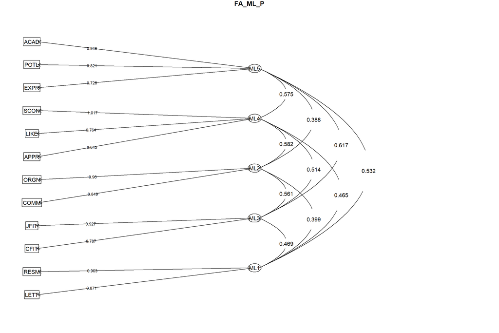

```r
##################################
# Graph the factor loading matrices
##################################
fa.diagram(FA_ML_P_5F,
           sort=TRUE,
           cut=0,
           digits=3,
           main="FA_ML_P",
           cex=0.75)
```

```r
##################################
# computing the internal consistency
# measure of reliability using the
# Cronbach's alpha coefficient
# for each factor
##################################
alpha(DPA.Descriptors.Numeric[,c("ACAD","POTL","EXPR")])
```

```
##
## Reliability analysis
## Call: alpha(x = DPA.Descriptors.Numeric[, c("ACAD", "POTL", "EXPR")])
##
##   raw_alpha std.alpha G6(smc) average_r S/N   ase mean  sd median_r
##       0.89      0.89    0.85      0.72 7.8 0.028  7.3 1.2      0.7
##
##     95% confidence boundaries
##          lower alpha upper
## Feldt     0.82  0.89  0.93
## Duhachek  0.83  0.89  0.94
##
##  Reliability if an item is dropped:
##      raw_alpha std.alpha G6(smc) average_r S/N alpha se var.r med.r
## ACAD      0.83      0.83    0.70      0.70 4.7    0.049    NA  0.70
## POTL      0.80      0.80    0.67      0.67 4.0    0.056    NA  0.67
## EXPR      0.88      0.89    0.80      0.80 7.8    0.032    NA  0.80
##
##  Item statistics
##       n raw.r std.r r.cor r.drop mean  sd
## ACAD 50  0.91  0.91  0.85   0.79  7.4 1.3
## POTL 50  0.92  0.92  0.88   0.82  7.3 1.4
## EXPR 50  0.88  0.88  0.76   0.72  7.3 1.4
##
## Non missing response frequency for each item
##         4    5    6    7    8    9   10 miss
## ACAD 0.02 0.02 0.22 0.28 0.24 0.18 0.04    0
## POTL 0.04 0.06 0.18 0.22 0.30 0.18 0.02    0
## EXPR 0.00 0.10 0.20 0.24 0.24 0.18 0.04    0
```

```r
alpha(DPA.Descriptors.Numeric[,c("SCON","LIKE","APPR")])
```

```
##
## Reliability analysis
## Call: alpha(x = DPA.Descriptors.Numeric[, c("SCON", "LIKE", "APPR")])
##
##   raw_alpha std.alpha G6(smc) average_r S/N   ase mean   sd median_r
##       0.87      0.87    0.83       0.7 6.9 0.031  7.4 0.99      0.7
##
##     95% confidence boundaries
##          lower alpha upper
## Feldt     0.80  0.87  0.92
## Duhachek  0.81  0.87  0.93
##
##  Reliability if an item is dropped:
##      raw_alpha std.alpha G6(smc) average_r S/N alpha se var.r med.r
## SCON      0.78      0.78    0.64      0.64 3.5    0.062    NA  0.64
## LIKE      0.82      0.82    0.70      0.70 4.6    0.051    NA  0.70
## APPR      0.86      0.86    0.75      0.75 6.1    0.040    NA  0.75
##
##  Item statistics
##       n raw.r std.r r.cor r.drop mean  sd
## SCON 50  0.92  0.91  0.86   0.80  7.3 1.2
## LIKE 50  0.90  0.89  0.82   0.76  7.4 1.1
## APPR 50  0.86  0.87  0.76   0.71  7.4 1.0
##
## Non missing response frequency for each item
##         4    5    6    7    8    9   10 miss
## SCON 0.00 0.08 0.14 0.32 0.28 0.18 0.00    0
## LIKE 0.02 0.04 0.12 0.32 0.36 0.14 0.00    0
## APPR 0.00 0.02 0.16 0.32 0.38 0.10 0.02    0
```

```r
alpha(DPA.Descriptors.Numeric[,c("ORGN","COMM")])
```

```
##
## Reliability analysis
## Call: alpha(x = DPA.Descriptors.Numeric[, c("ORGN", "COMM")])
##
##   raw_alpha std.alpha G6(smc) average_r S/N   ase mean  sd median_r
##       0.92      0.93    0.86      0.86  12 0.021  6.9 1.5     0.86
##
##     95% confidence boundaries
##          lower alpha upper
## Feldt     0.87  0.92  0.96
## Duhachek  0.88  0.92  0.97
##
##  Reliability if an item is dropped:
##      raw_alpha std.alpha G6(smc) average_r S/N alpha se var.r med.r
## ORGN      0.92      0.86    0.74      0.86 6.2       NA     0  0.86
## COMM      0.80      0.86    0.74      0.86 6.2       NA     0  0.86
##
##  Item statistics
##       n raw.r std.r r.cor r.drop mean  sd
## ORGN 50  0.97  0.96   0.9   0.86  6.9 1.6
## COMM 50  0.96  0.96   0.9   0.86  6.9 1.5
##
## Non missing response frequency for each item
##         3    4    5   6    7    8    9   10 miss
## ORGN 0.02 0.04 0.20 0.1 0.24 0.24 0.16 0.00    0
## COMM 0.04 0.04 0.06 0.2 0.30 0.28 0.06 0.02    0
```

```r
alpha(DPA.Descriptors.Numeric[,c("RESM","LETT")])
```

```
##
## Reliability analysis
## Call: alpha(x = DPA.Descriptors.Numeric[, c("RESM", "LETT")])
##
##   raw_alpha std.alpha G6(smc) average_r S/N   ase mean  sd median_r
##       0.91      0.91    0.84      0.84  10 0.025  7.2 1.6     0.84
##
##     95% confidence boundaries
##          lower alpha upper
## Feldt     0.84  0.91  0.95
## Duhachek  0.86  0.91  0.96
##
##  Reliability if an item is dropped:
##      raw_alpha std.alpha G6(smc) average_r S/N alpha se var.r med.r
## RESM      0.84      0.84     0.7      0.84 5.1       NA     0  0.84
## LETT      0.83      0.84     0.7      0.84 5.1       NA     0  0.84
##
##  Item statistics
##       n raw.r std.r r.cor r.drop mean  sd
## RESM 50  0.96  0.96  0.88   0.84  7.2 1.7
## LETT 50  0.96  0.96  0.88   0.84  7.2 1.7
##
## Non missing response frequency for each item
##         4    5    6    7    8    9   10 miss
## RESM 0.08 0.06 0.22 0.18 0.16 0.24 0.06    0
## LETT 0.06 0.12 0.14 0.22 0.24 0.12 0.10    0
```

```r
alpha(DPA.Descriptors.Numeric[,c("JFIT","CFIT")])
```

```
##
## Reliability analysis
## Call: alpha(x = DPA.Descriptors.Numeric[, c("JFIT", "CFIT")])
##
##   raw_alpha std.alpha G6(smc) average_r S/N   ase mean  sd median_r
##       0.94      0.94    0.88      0.88  15 0.018    7 1.6     0.88
##
##     95% confidence boundaries
##          lower alpha upper
## Feldt     0.89  0.94  0.96
## Duhachek  0.90  0.94  0.97
##
##  Reliability if an item is dropped:
##      raw_alpha std.alpha G6(smc) average_r S/N alpha se var.r med.r
## JFIT      0.87      0.88    0.78      0.88 7.5       NA     0  0.88
## CFIT      0.90      0.88    0.78      0.88 7.5       NA     0  0.88
##
##  Item statistics
##       n raw.r std.r r.cor r.drop mean  sd
## JFIT 50  0.97  0.97  0.91   0.88  7.0 1.6
## CFIT 50  0.97  0.97  0.91   0.88  6.9 1.6
##
## Non missing response frequency for each item
##         3    4    5    6    7    8    9   10 miss
## JFIT 0.06 0.00 0.06 0.22 0.26 0.24 0.12 0.04    0
## CFIT 0.02 0.06 0.16 0.12 0.22 0.30 0.08 0.04    0
```

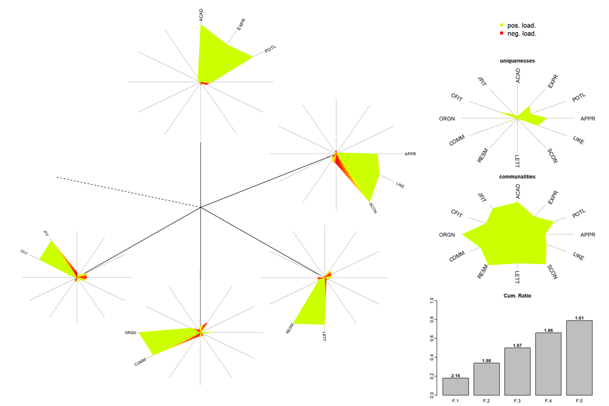

```r
##################################
# Formulating the dandelion plot to
# visualize both factor variances and loadings
# from the factor loading matrices
##################################
FA_ML_P_5F_FactorLoading <- factload(DPA.Descriptors.Numeric,
                                  cormeth = "pearson",
                                  method = "mle",
                                  nfac = 5,
                                  rotation = "promax")

DandelionPlotPalette <- rev(rainbow(100, start = 0, end = 0.2))

dandelion(FA_ML_P_5F_FactorLoading,
          bound=0,
          mcex=c(1,1.2),
          palet=DandelionPlotPalette)
```

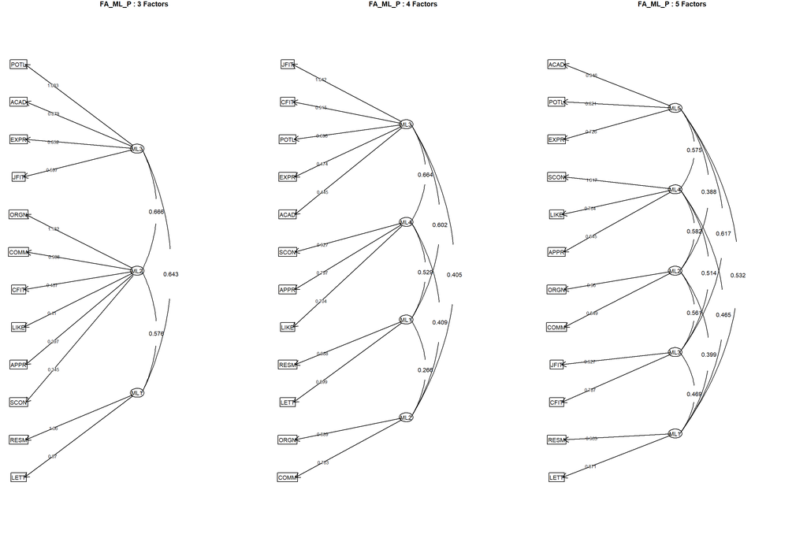

```r
par(mfrow=c(1,3))
fa.diagram(FA_ML_P_3F,
           sort=TRUE,
           cut=0,
           digits=3,
           main="FA_ML_P : 3 Factors",
           cex=0.75)
fa.diagram(FA_ML_P_4F,
           sort=TRUE,
           cut=0,
           digits=3,
           main="FA_ML_P : 4 Factors",
           cex=0.75)
fa.diagram(FA_ML_P_5F,
           sort=TRUE,
           cut=0,
           digits=3,
           main="FA_ML_P : 5 Factors",
           cex=0.75)
```

**Code Chunk | Output**

# **2. References**

**[Book]** [Multiple Factor Analysis by Example Using R](https://www.oreilly.com/library/view/multiple-factor-analysis/9781498786690/) by Jerome Pages  
**[Book]** [Nonlinear Principal Component Analysis and Its Applications](https://link.springer.com/book/10.1007/978-981-10-0159-8#toc) by Yuichi Mori, Masahiro Kuroda and Naomichi Makino  
**[Book]** [Applied Predictive Modeling](http://appliedpredictivemodeling.com/) by Max Kuhn and Kjell Johnson  
**[Book]** [An Introduction to Statistical Learning](https://www.statlearning.com/) by Gareth James, Daniela Witten, Trevor Hastie and Rob Tibshirani  
**[Book]** [Multivariate Data Visualization with R](http://lmdvr.r-forge.r-project.org/figures/figures.html) by Deepayan Sarkar  
**[Book]** [Machine Learning](https://bookdown.org/ssjackson300/Machine-Learning-Lecture-Notes/) by Samuel Jackson  
**[Book]** [Data Modeling Methods](https://bookdown.org/larget_jacob/data-modeling-methods/) by Jacob Larget  
**[Book]** [Introduction to R and Statistics](https://saestatsteaching.tech/) by University of Western Australia  
**[Book]** [Feature Engineering and Selection: A Practical Approach for Predictive Models](http://www.feat.engineering/index.html) by Max Kuhn and Kjell Johnson  
**[Book]** [Introduction to Research Methods](https://bookdown.org/ejvanholm/Textbook/) by Eric van Holm  
**[Book]** [A Step-by-Step Guide to Exploratory Factor Analysis with R and RStudio](https://www.taylorfrancis.com/books/mono/10.4324/9781003120001/step-step-guide-exploratory-factor-analysis-rstudio-marley-watkins) by Marley Watkins  
**[R Package]** [AppliedPredictiveModeling](https://cran.r-project.org/web//packages/AppliedPredictiveModeling/AppliedPredictiveModeling.pdf) by Max Kuhn  
**[R Package]** [caret](https://topepo.github.io/caret/index.html) by Max Kuhn  
**[R Package]** [rpart](https://mran.microsoft.com/web/packages/rpart/rpart.pdf) by Terry Therneau and Beth Atkinson  
**[R Package]** [lattice](https://cran.r-project.org/web/packages/lattice/lattice.pdf) by Deepayan Sarkar  
**[R Package]** [dplyr](https://cran.r-project.org/web/packages/dplyr/index.html/) by Hadley Wickham  
**[R Package]** [moments](https://cran.r-project.org/web/packages/moments/index.html) by Lukasz Komsta and Frederick  
**[R Package]** [skimr](https://cran.r-project.org/web/packages/skimr/skimr.pdf) by Elin Waring  
**[R Package]** [RANN](https://cran.r-project.org/web/packages/RANN/RANN.pdf) by Sunil Arya, David Mount, Samuel Kemp and Gregory Jefferis  
**[R Package]** [corrplot](https://cran.r-project.org/web/packages/corrplot/corrplot.pdf) by Taiyun Wei  
**[R Package]** [tidyverse](https://cran.r-project.org/web/packages/tidyverse/tidyverse.pdf) by Hadley Wickham  
**[R Package]** [lares](https://cran.rstudio.com/web/packages/lares/lares.pdf) by Bernardo Lares  
**[R Package]** [DMwR](https://mran.microsoft.com/snapshot/2016-05-02/web/packages/DMwR/DMwR.pdf) by Luis Torgo  
**[R Package]** [gridExtra](https://cran.r-project.org/web/packages/gridExtra/gridExtra.pdf) by Baptiste Auguie and Anton Antonov  
**[R Package]** [rattle](https://cran.r-project.org/web/packages/rattle/rattle.pdf) by Graham Williams  
**[R Package]** [RColorBrewer](https://cran.r-project.org/web//packages/RColorBrewer/RColorBrewer.pdf) by Erich Neuwirth  
**[R Package]** [stats](https://search.r-project.org/R/refmans/stats/html/00Index.html) by R Core Team  
**[R Package]** [factoextra](https://cran.r-project.org/web/packages/factoextra/factoextra.pdf) by Alboukadel Kassambara and Fabian Mundt  
**[R Package]** [FactoMineR](https://search.r-project.org/R/refmans/stats/html/00Index.html) by Francois Husson, Julie Josse, Sebastien Le and Jeremy Mazet  
**[R Package]** [gplots](https://cran.r-project.org/web/packages/gplots/gplots.pdf) by Tal Galili  
**[R Package]** [qgraph](https://cran.r-project.org/web/packages/qgraph/qgraph.pdf) by Sacha Epskamp  
**[R Package]** [ggplot2](https://search.r-project.org/R/refmans/stats/html/00Index.html) by Hadley Wickham, Winston Chang, Lionel Henry and Thomas Lin Pedersen  
**[R Package]** [psych](https://cran.r-project.org/web/packages/psych/psych.pdf) by William Revelle  
**[R Package]** [nFactors](https://cran.r-project.org/web/packages/nFactors/nFactors.pdf) by Gilles Raiche and David Magis  
**[R Package]** [MBESS](https://cran.r-project.org/web/packages/MBESS/MBESS.pdf) by Ken Kelley  
**[R Package]** [DandEFA](https://cran.r-project.org/web/packages/DandEFA/DandEFA.pdf) by Artur Manukyan, Ahmet Sedef, Erhan Cene and Ibrahim Demir  
**[R Package]** [EFAtools](https://cran.r-project.org/web/packages/EFAtools/EFAtools.pdf) by Markus Steiner and Silvia Grieder  
**[R Package]** [parameters](https://cran.r-project.org/web/packages/parameters/parameters.pdf) by Daniel Ludecke  
**[R Package]** [performance](https://cran.r-project.org/web/packages/performance/performance.pdf) by Daniel Ludecke  
**[Article]** [6 Dimensionality Reduction Techniques in R (with Examples)](https://cmdlinetips.com/2022/07/dimensionality-reduction-techniques-in-r/) by CMDLineTips Team  
**[Article]** [6 Dimensionality Reduction Algorithms With Python](https://machinelearningmastery.com/dimensionality-reduction-algorithms-with-python/) by Jason Brownlee  
**[Article]** [Introduction to Dimensionality Reduction for Machine Learning](https://machinelearningmastery.com/dimensionality-reduction-for-machine-learning/) by Jason Brownlee  
**[Article]** [Introduction to Dimensionality Reduction](https://www.geeksforgeeks.org/dimensionality-reduction/) by Geeks For Geeks  
**[Article]** [Factor Analysis with the psych package](https://m-clark.github.io/posts/2020-04-10-psych-explained/) by Michael Clark  
**[Article]** [Factor Analysis in R with Psych Package: Measuring Consumer Involvement](https://www.r-bloggers.com/2019/01/factor-analysis-in-r-with-psych-package-measuring-consumer-involvement/) by Peter Prevos  
**[Article]** [Factor Analysis in R](http://jinjian-mu.com/tutorial/2021-04-14-Factor%20Analysis/) by Jinjian Mu  
**[Article]** [How To: Use the psych package for Factor Analysis and Data Reduction](http://personality-project.org/r/psych/HowTo/factor.pdf) by William Revelle  
**[Article]** [A Practical Introduction to Factor Analysis: Exploratory Factor Analysis](https://stats.oarc.ucla.edu/spss/seminars/introduction-to-factor-analysis/a-practical-introduction-to-factor-analysis/) by UCLA Advanced Research Computing Team  
**[Article]** [Examining the Big 5 Personality Dataset with Factor Analysis](https://taridwong.github.io/posts/2022-01-01-efacfa/) by Tarid Wongvorachan  
**[Article]** [Principal Component Analysis versus Exploratory Factor Analysis](https://support.sas.com/resources/papers/proceedings/proceedings/sugi30/203-30.pdf) by Diana Suhr  
**[Article]** [Exploratory Factor Analysis](https://www.publichealth.columbia.edu/research/population-health-methods/exploratory-factor-analysis) by Columbia University Irving Medical Center  
**[Article]** [Factor Analysis Example](https://real-statistics.com/multivariate-statistics/factor-analysis/factor-analysis-example/) by Charles Zaiontz  
**[Article]** [Factor Analysis Guide with an Example](https://statisticsbyjim.com/basics/factor-analysis/) by Jim Frost  
**[Article]** [What Is Factor Analysis and How Does It Simplify Research Findings?](https://www.qualtrics.com/experience-management/research/factor-analysis/) by Qualtrics Team  
**[Article]** [How Can I Perform A Factor Analysis With Categorical (Or Categorical And Continuous) Variables?](https://stats.oarc.ucla.edu/stata/faq/how-can-i-perform-a-factor-analysis-with-categorical-or-categorical-and-continuous-variables/) by UCLA Advanced Research Computing Team  
**[Article]** Factor Analysis on Ordinal Data Example in R (psych, homals) by Jiayu Wu  
**[Publication]** [Dandelion Plot: A Method for the Visualization of R-mode Exploratory Factor Analyses](https://link.springer.com/article/10.1007/s00180-014-0518-x) by Artur Manukyan, Erhan Cene, Ahmet Sedef and Ibrahim Demir (Computational Statistics)  
**[Course]** [Applied Data Mining and Statistical Learning](https://online.stat.psu.edu/stat508/) by Penn State Eberly College of Science